# Systematic review and analysis of immunisation administration costs across Africa

Estimating the costs of malaria vaccine implementation

Joe Brew and Elisa Sicuri

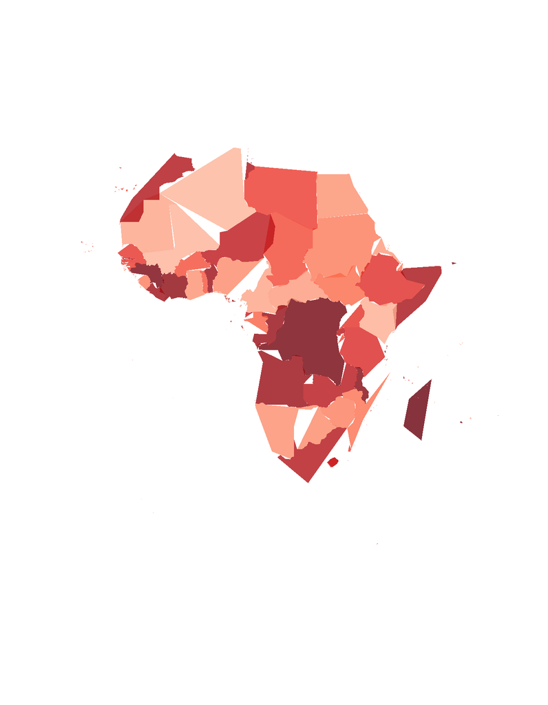

# Introduction

## Context

This document provides an overview of the GSK malaria immunisation costing estimation. This project is being carried out under the direction of Dr. Elisa Sicuri. Its purpose is to provide country-specific estimates for the non-vaccine costs of implementing large-scale malaria immunisation across sub-saharan Africa. It is considered a “work in progress” and is intended for further review and revisions prior to publication.

## Justification

Given that the a truly large-scale Malaria vaccination campaign has *never* taken place, it is impossible to know Malaria immunisation unit costs through direct prior experience. However, it is possible to estimate these costs indirectly by gathering data on the costs of other vaccination campaigns over the last two decades.

This study aims to estimate the non-vaccine costs of widespread Malaria vaccination implementation across Africa via the collection, itemization and standardization of vaccine cost studies in the literature. Its results provide estimates of *likely* costs to be incurred by Malaria immunisation programmes.

# Methods

## Data collection

### Search strategy

For the purposes of both transparency and future reproducibility, we use a standard and automated search strategy. Our time frame of interest is 2000 to present day (June, 2016). Our search query is `"'((vaccine) OR (vaccination) OR (immunization)) AND (cost) AND (africa)'"`. The code for retrieving the papers and abstracts from PubMed (in the `"R"` programming language) is available [here](https://github.com/joebrew/gsk/blob/master/search_pubmed.R).

## Data aggregation and cleaning

### Itemization and data extraction

Having finished selection, we extract from each study the itemized costs of immunization, excluding the actual purchase of vaccine. The categories are:

- Equipment: Materials and supplies, such as syringes, needle disposal boxes, bandages, paper, etc.
- Human resources: All human labor costs, including salary and wages.
- Sensitisation: All public awareness, advertising or other opinion-influencing actiity.
- Training: Education and training for programme personnel, other than that which they would have already received independely of programme existence.
- Transportation: All costs associated with moving vaccine and/or personnel and/or supplies for the vaccination campaign, including (but not limited to) cold storage.
- Wastage: Any non-productive cost.
- Administration: All non-vaccine, non-material, and non-personnel costs related to the actual delivery of the vaccine, once at a health facility or other site of immunisation, not covered in any of the below categories.

In some cases, all of the above items were available. In most, only some of them were disclosed. In many cases, costs were given as a percentage of total, rather than in currency.

### Cost types

Studies variably reported cost “types” such as fixed, in-kind, recurring, start-up, variable, etc. These categories were often overlapping and incompatible. They are intentionally excluded due to the lack of comparability across studies.

By the same token, a minority of studies noted, albeit indirectly, the distinction between economic and financial costs. To the extent that this distinction was infrequent and inconsistent, it is also ignored.

We distinguished between “trial” studies (also referred to as “campaign” or “non-routine”), and those implementing more regularly administered vaccines (referred to simply as “routine”) Likewise, we distinguished between studies pertaining to the “introduction” of a vaccine in an area for the first time, versus those that pertained to costing of a vaccine that was already in place, ie “non-introduction”.

Among our studies, all trial costs happened to be from non-introduction studies (ie, they were trials of a vaccine that was already used in some shape or form), whereas non-trial studies where sometimes introductory in nature (approximatey 1/3 of non-trial studies) and the majority was non-introductory.

### Final inclusion dataset

After selection, we itemized our data into article-cost type pairings.

The raw itemized data is below:

|  | DISEASE | DOSES | TYPE | SOURCE | LINK | YEAR | COUNTRY | COST | COUNTRY NAME | GDP | TRIAL | INTRODUCTION |
| --- | --- | --- | --- | --- | --- | --- | --- | --- | --- | --- | --- | --- |
| 1 | MULTIPLE | 1 | Wastage | An economic evaluation of thermostable vaccines in Cambodia, Ghana and Bangladesh. | http://www.sciencedirect.com/science/article/pii/S0264410X0700758X | 2002 | Multiple | 0.406212663822866 |  | 411.959075281789 | False | False |
| 2 | MULTIPLE | 1 | Transportation | An economic evaluation of thermostable vaccines in Cambodia, Ghana and Bangladesh. | http://www.sciencedirect.com/science/article/pii/S0264410X0700758X | 2002 | Ghana | 0.040194 | Ghana | 311.616825027768 | False | False |
| 3 | MULTIPLE | 1 | Transportation | An economic evaluation of thermostable vaccines in Cambodia, Ghana and Bangladesh. | http://www.sciencedirect.com/science/article/pii/S0264410X0700758X | 2002 | Ghana | 0.120582 | Ghana | 311.616825027768 | False | False |
| 4 | MEASLES | 1 | Wastage | An economic evaluation of thermostable vaccines in Cambodia, Ghana and Bangladesh. | http://www.sciencedirect.com/science/article/pii/S0264410X0700758X | 2002 | Ghana | 6.49940262116585 | Ghana | 311.616825027768 | False | False |
| 5 | MEASLES | 1 | Wastage | An economic evaluation of thermostable vaccines in Cambodia, Ghana and Bangladesh. | http://www.sciencedirect.com/science/article/pii/S0264410X0700758X | 2002 | Ghana | 5.07765829778582 | Ghana | 311.616825027768 | False | False |
| 6 | MULTIPLE | 1 | Human resources | Cost analysis of routine immunisation in Zambia | http://www.sciencedirect.com.sire.ub.edu/science/article/pii/S0264410X14016934 | 2011 | Zambia | 12.3691756134063 | Zambia | 1635.54730435222 | False | False |
| 7 | MULTIPLE | 1 | Equipment | Cost analysis of routine immunisation in Zambia | http://www.sciencedirect.com.sire.ub.edu/science/article/pii/S0264410X14016934 | 2011 | Zambia | 3.43249700930322 | Zambia | 1635.54730435222 | False | False |
| 8 | MULTIPLE | 1 | Administration | Cost analysis of routine immunisation in Zambia | http://www.sciencedirect.com.sire.ub.edu/science/article/pii/S0264410X14016934 | 2011 | Zambia | 0.670250895307729 | Zambia | 1635.54730435222 | False | False |
| 9 | MULTIPLE | 1 | Transportation | Cost analysis of routine immunisation in Zambia | http://www.sciencedirect.com.sire.ub.edu/science/article/pii/S0264410X14016934 | 2011 | Zambia | 1.48267622295346 | Zambia | 1635.54730435222 | False | False |
| 10 | HEPATITIS B | 1 | Transportation | Cost-effectiveness analysis of an additional birth dose of Hepatitis B vaccine to prevent perinatal transmission in a medical setting in Mozambique. | http://www.sciencedirect.com/science/article/pii/S0264410X12011735 | 2008 | Mozambique | 0.414215 | Mozambique | 499.887085818156 | False | False |

[output cut: 149 more lines]

### Currency standardization

Following itemization, we standardize all costs from local currencies and past values to the equivalent of 2016 United States Dollars. For currency conversion from local to US dollars, we use publicly available exchange rates from [Quandl](https://www.quandl.com/collections/usa/usa-currency-exchange-rate).

For inflation adjustment, we use the “Consumer Price Index” from the [United States Bureau of Labor and Statistics](http://data.bls.gov/cgi-bin/cpicalc.pl).

|  | Date | 2016 USD % |
| --- | --- | --- |
| 1 | 1980 | 292.52 |
| 2 | 1981 | 265.17 |
| 3 | 1982 | 249.78 |
| 4 | 1983 | 242.01 |
| 5 | 1984 | 231.99 |
| 6 | 1985 | 224.01 |
| 7 | 1986 | 219.93 |
| 8 | 1987 | 212.18 |
| 9 | 1988 | 203.75 |
| 10 | 1989 | 194.39 |

[output cut: 27 more lines]

All costs reported herein are in 2016 US Dollars.

### Purchasing price parity

We also adjust currency for purchasing price parity, as estimated by the World Bank (Bank 2015). For our purposes, “adjustment” refers to the process by which we convert from local currency to 2016 USD in PPP. In many cases, this meant “back-engineering” the local currency, since original papers often report in USD.

Below is a table of the PPP values used for this conversion. Full code for the “back-engineering” is available on this paper’s github repository (Brew 2017).

|  | Country | 2000 | 2001 | 2002 | 2003 | 2004 | 2005 | 2006 | 2007 | 2008 | 2009 | 2010 | 2011 | 2012 | 2013 | 2014 | 2015 |
| --- | --- | --- | --- | --- | --- | --- | --- | --- | --- | --- | --- | --- | --- | --- | --- | --- | --- |
| 1 | Afghanistan |  |  | 9.64 | 10.56 | 11.43 | 12.28 | 12.77 | 15.22 | 15.25 | 14.82 | 16.02 | 17.36 | 18.46 | 19.02 | 18.73 | 19.24 |
| 2 | Albania | 41.85 | 42.28 | 42.65 | 44.06 | 43.89 | 43.64 | 41.72 | 42.54 | 41.81 | 41.83 | 45.74 | 46.45 | 44.35 | 44.78 | 43.34 | 44.18 |
| 3 | Algeria | 16.34 | 15.9 | 15.86 | 16.85 | 18.41 | 20.71 | 22.21 | 23.02 | 26.03 | 22.95 | 26.33 | 30.5 | 32.18 | 31.64 | 30.95 | 28.78 |
| 4 | Angola | 2 | 4.04 | 11.81 | 21.41 | 29.13 | 35.79 | 39.25 | 43.06 | 50.54 | 46.44 | 56.15 | 68.31 | 71.82 | 72.45 | 70.2 | 66.66 |
| 5 | Antigua and Barbuda | 1.78 | 1.77 | 1.76 | 1.71 | 1.69 | 1.71 | 1.67 | 1.68 | 1.72 | 1.74 | 1.74 | 1.73 | 1.75 | 1.72 | 1.64 | 1.61 |
| 6 | Argentina | 0.65 | 0.63 | 0.81 | 0.87 | 1.01 | 1.08 | 1.19 | 1.33 | 1.61 | 1.84 | 2.2 | 2.66 | 3.2 | 3.9 | 5.39 | 6.6 |
| 7 | Armenia | 144.93 | 147.47 | 148.68 | 152.42 | 157.7 | 157.74 | 160.11 | 162.56 | 168.98 | 171.99 | 183.12 | 187.1 | 193.53 | 196.87 | 197.87 | 198.07 |
| 8 | Aruba |  |  |  |  |  |  |  |  |  |  |  | 1.26 |  |  |  |  |
| 9 | Australia | 1.31 | 1.33 | 1.34 | 1.36 | 1.37 | 1.39 | 1.4 | 1.43 | 1.48 | 1.44 | 1.5 | 1.51 | 1.54 | 1.45 | 1.47 | 1.49 |
| 10 | Austria | 0.9 | 0.92 | 0.9 | 0.88 | 0.87 | 0.89 | 0.86 | 0.87 | 0.85 | 0.84 | 0.84 | 0.84 | 0.82 | 0.8 | 0.81 | 0.82 |

[output cut: 191 more lines]

### Dose standardization

Some papers reported costs per fully immunized person (ie, multiple doses), whereas others reported per dose. For the sake of comparability, all costs were converted to be per dose.

## Data analysis

### Point estimates and distributions

Having gathered and standardized item-specific vaccination programme costs, we estimate ranges for each item cost. Given the incompatibility of currency and percentage data, whenever possible we convert percentage data to 2016 USD, using available data to estimate overall cost. Additionally, since the range of estimates is high, we include distributions in all visualizations.

### Geospatial determinants of vaccine cost

Having estimated the cost of vaccine implementation after standardization for time and currency, we can construct a continuous interpolated surface (raster) for vaccine cost. This allows us to generate country and region-specific estimates. We construct this surface through the use of a generalized additive model (GAM) using bivariate adaptive smoothing for the spatial (latitude and longitude) inputs. This method employs “basis penalties” to estimate the spatial effect on cost without overfitting to each country’s location, and is useful in estimating spatial effects with incomplete information (Wheeler and Siangphoe 2015, Li et al. (2012), Young et al. (2010), French (2004)).

The rationale for using a spatial model to estimate costs is two-fold. First, a spatial model has the advantage of capturing simply geopolitical, cultural and economic characteristics which are difficult to observe or quantify or would lead to such a wide-dimensioned model so as to be unstable. Second, a smoothed spatial model allows for generalizability to other locations within the range of the model’s training locations (ie, Sub-Saharan Africa).

Given that most studies are at the regional and national levels, country centroids are used for locations. Sub-national breakdowns are not taken into consideration.

### Modeling

In addition to the country- and region-specific implementation costs estimation, we estimate the effect of macroeconomic factors (GDP per capita) on costs. Though GDP per capita is geospatially autocorrelated, we apply a flexible smoothing algorithm to location, whereas we carry out no smoothing for GDP. We include these determinants into a final generalized additive model, which will be applicable for cross-continent cost estimation.

# Results

## Item selection

The initial query returned 985 results. We read the abstracts of all 985 papers, and eliminated 850 due to any of the following reasons:

- Geographic incompatibility (outside of sub-saharan Africa)
- Temporal incompatibility (outside of the time range in question)
- Subject matter irrelevance (non-human or animal vaccines, non-vaccines, opinion pieces, etc.)
- Lack of quantitative costing information

All 985 “original” papers, prior to manual exclusion, can be obtained [here](https://github.com/joebrew/gsk/blob/master/pubmed_results.csv?raw=true).

The first elimination round left 135 articles for manual inspection. All were read, and a further 94 were eliminated because they lacked itemized cost information, cost information was not clear, or the items listed were not categorized in a way as to make comparable to the larger body of literature.

The below diagram shows the flow of article selection:

[figure not shown]

### Selected studies

Below is a complete overview of all 41 studies that both matched the automated selection criteria *and* passed the manual filtering steps outlined above.

|  | Title | Year | Affiliation | All authors | Url |
| --- | --- | --- | --- | --- | --- |
| 1 | The cost of integrating hepatitis B virus vaccine into national immunization programmes: a case study from Addis Ababa. | 2000 | Department of Biological Sciences, University of Warwick, Coventry, UK. jedmunds@phls.nhs.uk | W Edmunds, A Dejene, Y Mekonnen, M Haile, W Alemnu, D Nokes | http://www.ncbi.nlm.nih.gov/pubmed/?term=11124244 |
| 2 | Comparison of cost-effectiveness of preventive and reactive mass immunization campaigns against meningococcal meningitis in West Africa: a theoretical modeling analysis. | 2001 | Association pour l'Aide à la Médecine Préventive, 28 rue du Docteur Roux, 75724 Cedex 15, Paris, France. iparent@compuserve.com | I Parent du Châtelet, B D Gessner, A da Silva | http://www.ncbi.nlm.nih.gov/pubmed/?term=11348706 |
| 3 | [Vaccination against viral hepatitis B for public health personnel: the case of the National Fund of Social Security]. | 2002 | Polyclinique El Khadra CNSS, Tunis, Tunisie. | N Saadallah, N Jaoua, A Ben Hamida, T Najjar, B Zouari | http://www.ncbi.nlm.nih.gov/pubmed/?term=11892442 |
| 4 | Cost-effectiveness of three different vaccination strategies against measles in Zambian children. | 2003 | Centers for Disease Control and Prevention, National Immunization Program, 1600 Clifton Road, Mailstop E-61, Atlanta, GA 30333, USA. gdayan@cdc.gov | Gustavo H Dayan, Lisa Cairns, Nalinee Sangrujee, Anne Mtonga, Van Nguyen, Peter Strebel | http://www.ncbi.nlm.nih.gov/pubmed/?term=14670330 |
| 5 | Impact of mass measles campaigns among children less than 5 years old in Uganda. | 2003 | Uganda Virus Research Institute, Ministry of Health, Entebbe, Uganda. mnanyunja@who.imul.com | Miriam Nanyunja, Rosamund F Lewis, Issa Makumbi, Rachel Seruyange, Eva Kabwongera, Possy Mugyenyi, Ambrose Talisuna | http://www.ncbi.nlm.nih.gov/pubmed/?term=12721893 |
| 6 | Economic analysis of the 1996-1997 mass measles immunization campaigns in South Africa. | 2004 | Global Immunization Division, National Immunization Program, Centers for Disease Control and Prevention, 1600 Clifton Road, MS E-05, Atlanta, GA 30333, USA. auzicanin@cdc.gov | Amra Uzicanin, Fangjun Zhou, Rudi Eggers, Elize Webb, Peter Strebel | http://www.ncbi.nlm.nih.gov/pubmed/?term=15308367 |
| 7 | [Microeconomic evaluation of a mass preventive immunisation campaign against meningococcal meningitis and yellow fever in Senegal in 1997]. | 2004 | Association pour l'aide à la médecine préventive, 25, rue du Dr Roux, 75724 Paris, France. aldasilva@compuserve.com | Alfred da Silva, Isabelle Parent du Châtelet, Abou Beckr Gaye, Jean-Pierre Dompnier, Ibrahima Seck | http://www.ncbi.nlm.nih.gov/pubmed/?term=15047438 |
| 8 | Feasibility of a mass vaccination campaign using a two-dose oral cholera vaccine in an urban cholera-endemic setting in Mozambique. | 2005 | Epicentre, Paris, France. philippe.cavailler@epicentre.msf.org | Philippe Cavailler, Marcelino Lucas, Valerie Perroud, Margaret McChesney, Sonia Ampuero, Philippe J Guérin, Dominique Legros, Thomas Nierle, Claude Mahoudeau, Bruno Lab, Pierre Kahozi, Jacqueline L De… | http://www.ncbi.nlm.nih.gov/pubmed/?term=S0264-410X(05)01042-X |
| 9 | Review of the cost effectiveness of immunisation strategies for the control of epidemic meningococcal meningitis. | 2005 | Division on International Epidemiology and Population Studies, Fogarty Internatonal Center, National Institutes of Health, Building 16, 16 Center Drive, Bethesda, MD 20892-6705, USA. millermark@nih.go… | Mark A Miller, Cathryn K Shahab | http://www.ncbi.nlm.nih.gov/pubmed/?term=2344 |
| 10 | The cost-effectiveness of introducing hepatitis B vaccine into infant immunization services in Mozambique. | 2005 | Department of Vaccines and Biologicals, World Health Organization, 20 Avenue Appia, 1211 Geneva 27, Switzerland. Griffithsu@who.int | Ulla K Griffiths, Guy Hutton, Eva Das Dores Pascoal | http://www.ncbi.nlm.nih.gov/pubmed/?term=20/1/50 |

[output cut: 31 more lines]

A full list is available in the appendix.

## Item-specific vaccination implementation estimates

The number of articles reporting specific costs for each category of item costs can be visualized below.

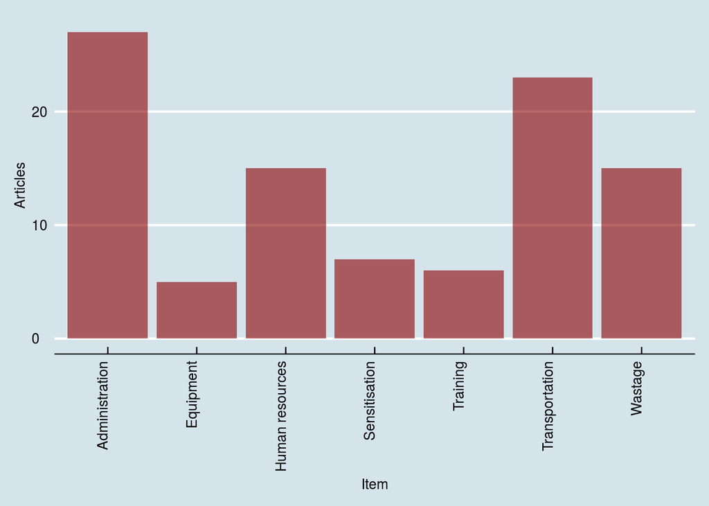

What follows is a table of the same data

|  | Item | Articles |
| --- | --- | --- |
| 1 | Administration | 27 |
| 2 | Equipment | 5 |
| 3 | Human resources | 15 |
| 4 | Sensitisation | 7 |
| 5 | Training | 6 |
| 6 | Transportation | 23 |
| 7 | Wastage | 15 |

A total of 19 country combinations were included in the final dataset. Their distribution can be visualized below.

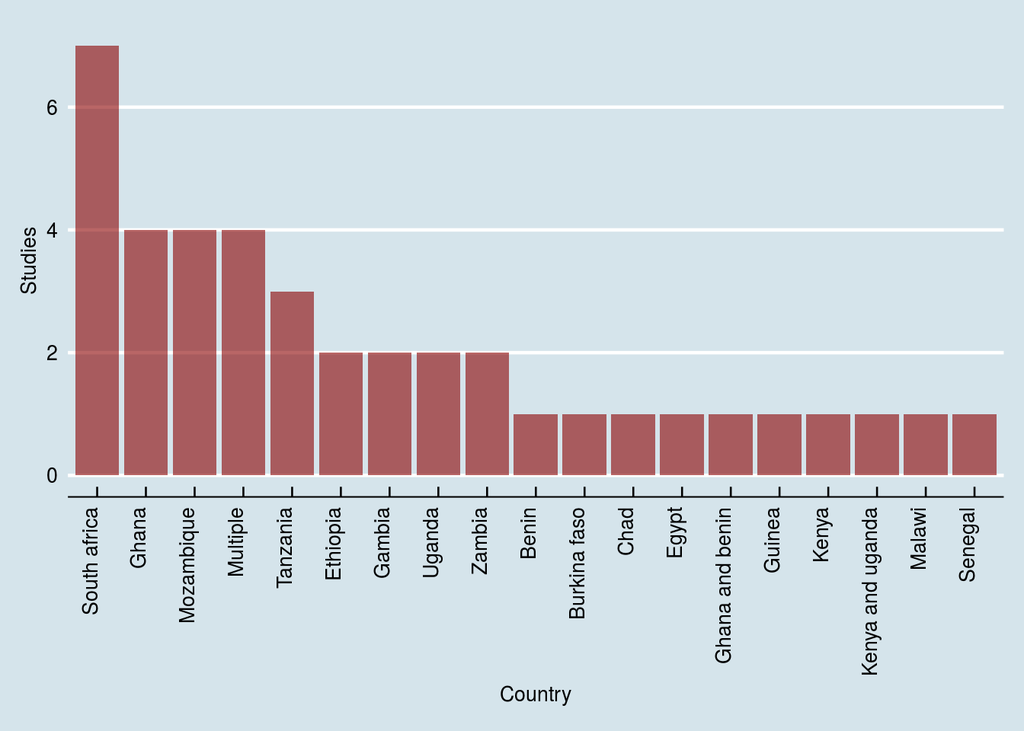

Below is a table of the same data.

|  | Country | Articles |
| --- | --- | --- |
| 1 | South africa | 7 |
| 2 | Ghana | 4 |
| 3 | Mozambique | 4 |
| 4 | Multiple | 4 |
| 5 | Tanzania | 3 |
| 6 | Ethiopia | 2 |
| 7 | Gambia | 2 |
| 8 | Uganda | 2 |
| 9 | Zambia | 2 |
| 10 | Benin | 1 |

[output cut: 9 more lines]

What follows are charts showing the distribution of dose-specific costs (both in currency and extrapolated from percentages) for each of the 7 implementation categories. The vertical line shows the average cost.

### Administration

The average administration cost per dose was close to $2 USD, with half of studies having an administration cost of less than $0.53.

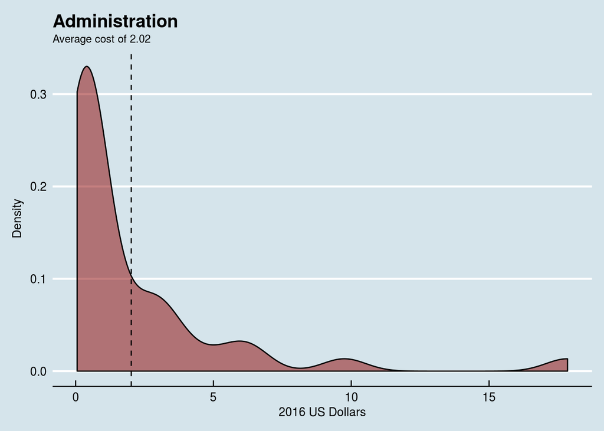

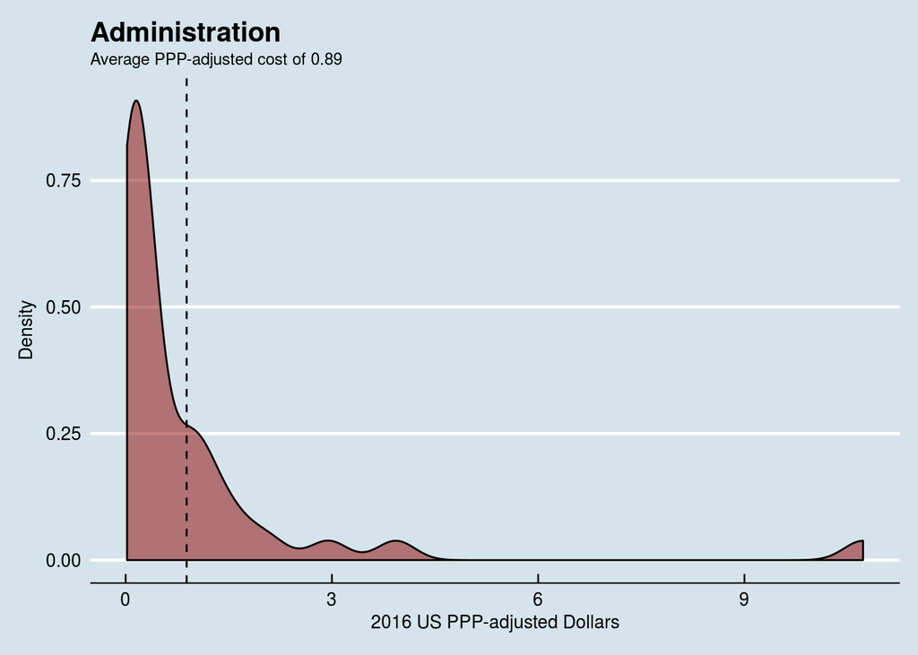

### Equipment

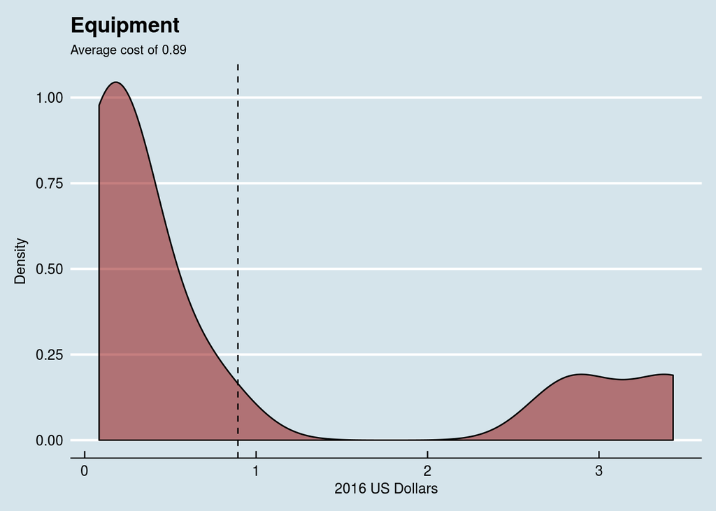

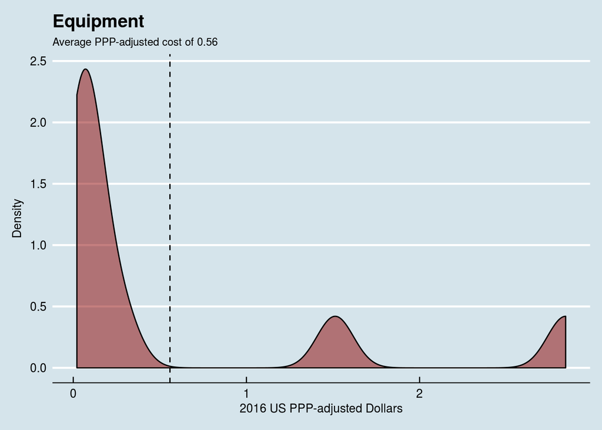

### Human resources

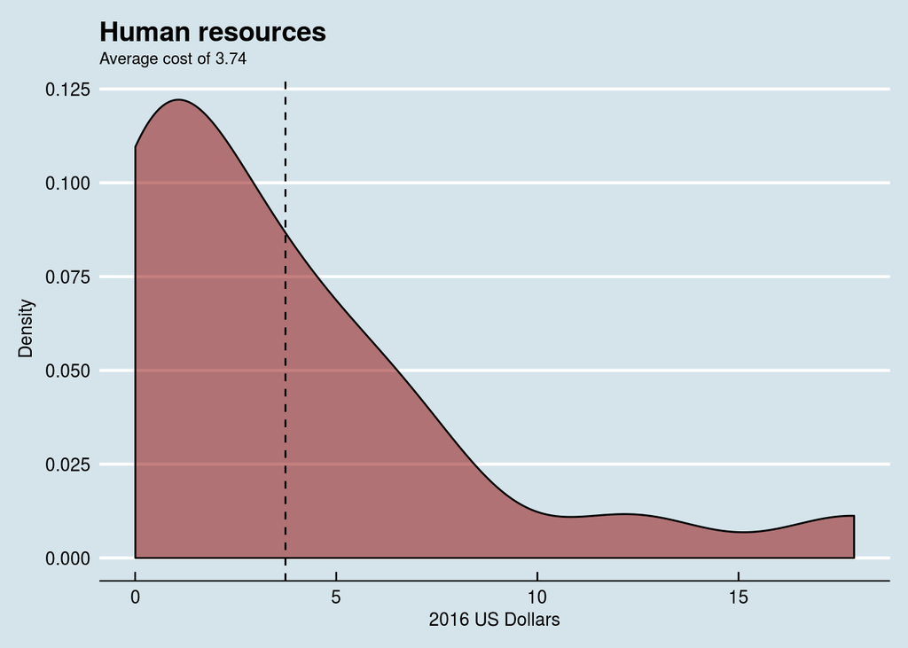

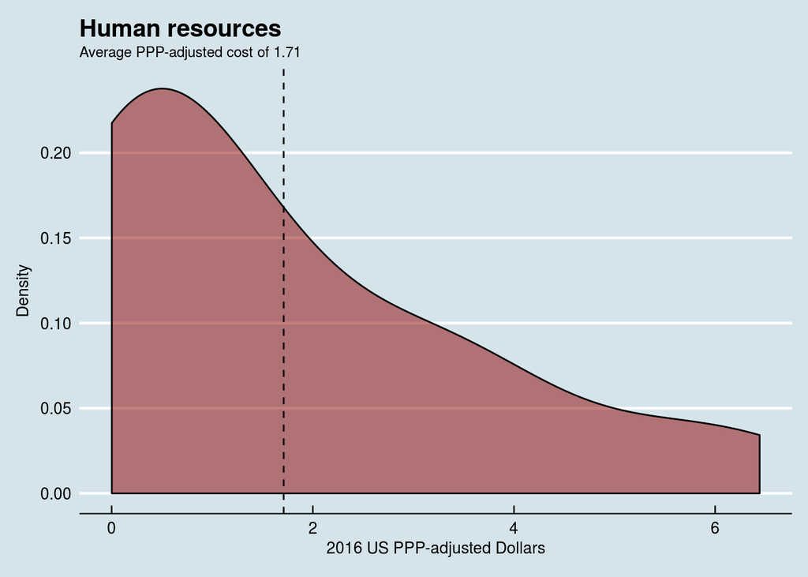

### Sensitisation

Sensitisation costs were low across all studies. One outlier - an oral cholera vaccine campaign in urban Mozambique - reported particularly high costs, but 90% of studies reported sensitisation costs of $0.20 or less.

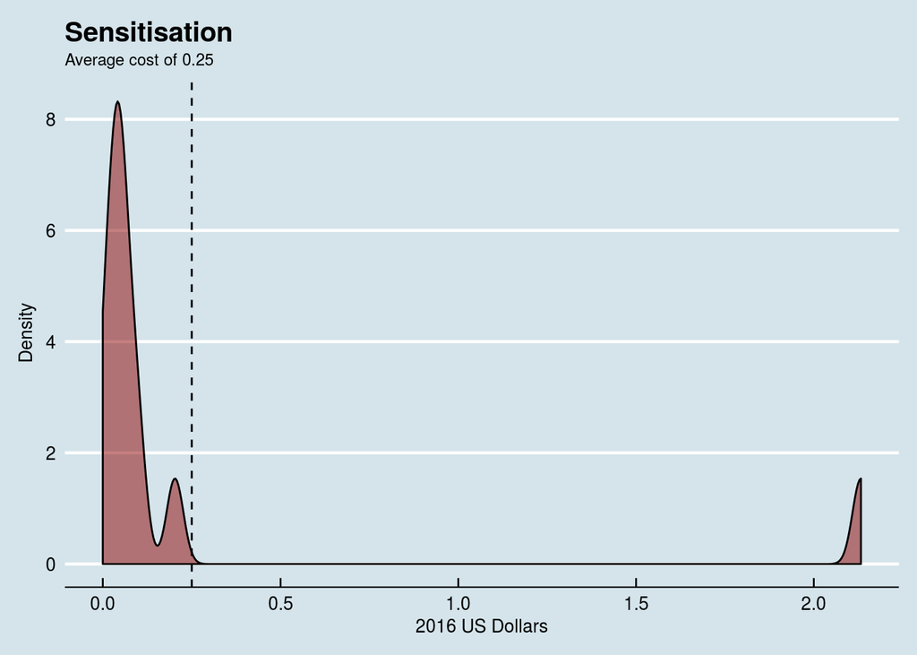

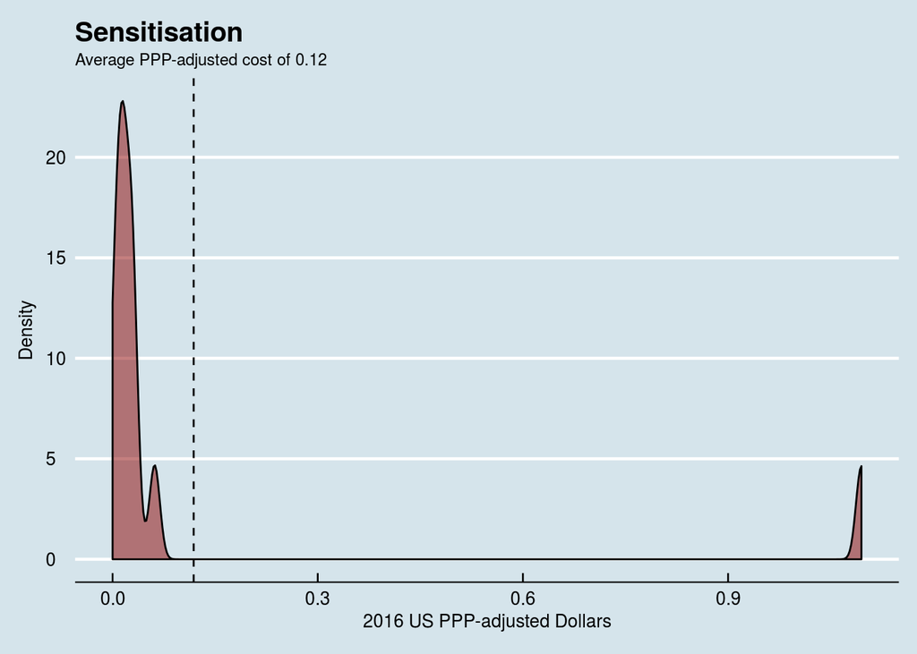

### Training

Training costs were low across all studies The highest training costs were associated with programs in which a new vaccine was introduced alongside another into an already existing national program.

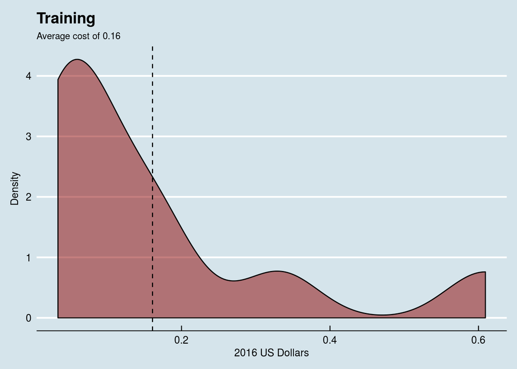

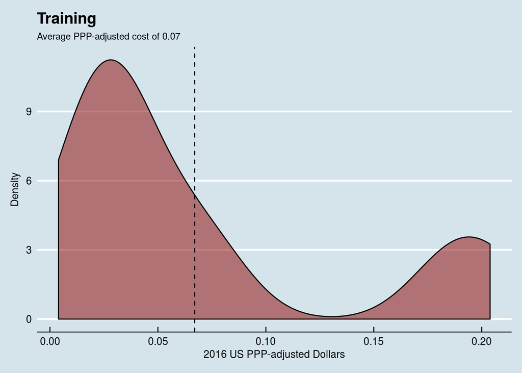

### Transportation

We observed wide variance in transporation costs. Though half of studies had costs of less than $0.67 USD, several studies had costs of more than $1 USD (and in one case, nearly $20 USD). The cause for this variation is not clear.

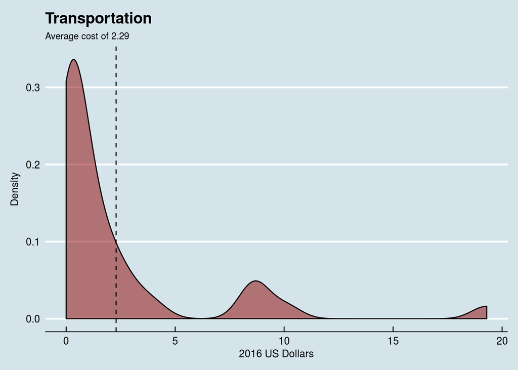

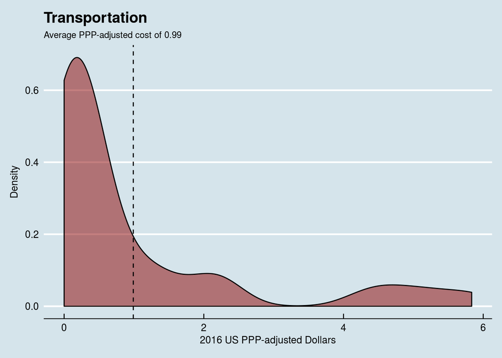

### Wastage

Wastage costs varied widely per study. Those with the highest costs involved Hepatitis B or jet injection vaccinations.

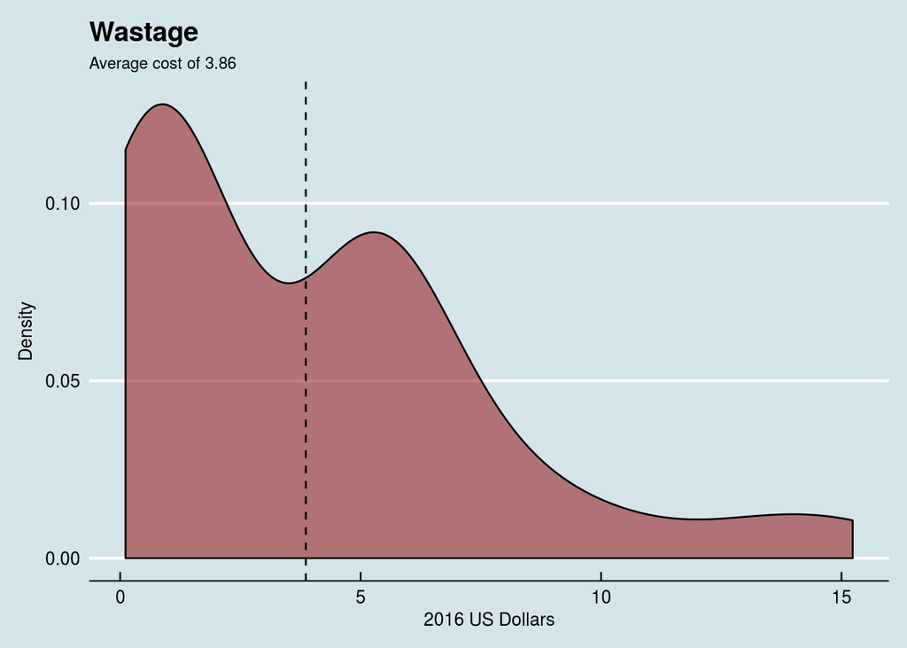

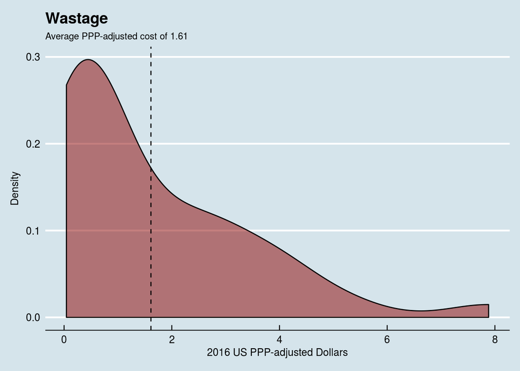

The below table shows the same costs.

|  | Item | Average | Maximum | Minimum | articles |
| --- | --- | --- | --- | --- | --- |
| 1 | Administration | 2.02 | 17.85 | 0.06 | 27 |
| 2 | Equipment | 0.89 | 3.43 | 0.08 | 5 |
| 3 | Human resources | 3.74 | 17.87 | 0 | 15 |
| 4 | Sensitisation | 0.25 | 2.13 | 0 | 7 |
| 5 | Training | 0.16 | 0.61 | 0.03 | 6 |
| 6 | Transportation | 2.29 | 19.3 | 0 | 23 |
| 7 | Wastage | 3.86 | 15.23 | 0.11 | 15 |

The below table is identical to the above, but using PPP-adjusted costs

|  | Item | Average | Maximum | Minimum | articles |
| --- | --- | --- | --- | --- | --- |
| 1 | Administration | 0.89 | 10.73 | 0.02 | 27 |
| 2 | Equipment | 0.56 | 2.84 | 0.02 | 5 |
| 3 | Human resources | 1.71 | 6.44 | 0 | 15 |
| 4 | Sensitisation | 0.12 | 1.09 | 0 | 7 |
| 5 | Training | 0.07 | 0.2 | 0 | 6 |
| 6 | Transportation | 0.99 | 5.83 | 0 | 23 |
| 7 | Wastage | 1.61 | 7.88 | 0.04 | 15 |

### Differences in cost estimations

Despite both quantitative and qualitative components to our analysis of which factors might account for the large differences in costs, we are unable to make conclusions in this area. Due to a lack of standardization in both (a) what is reported (some studies report all of the cost types we mention, others only a portion) and (b) how it is reported, studies are not directly comparable. Evidence for this exists in the below bar chart, showing the maximum cost for each expenditure type as a percentage of the minimum cost in the same category. Though some variance is to be expected, we suspect that much of the variance observed is not due to actual differences in cost, but rather due to differences in what is reported in each cost category.

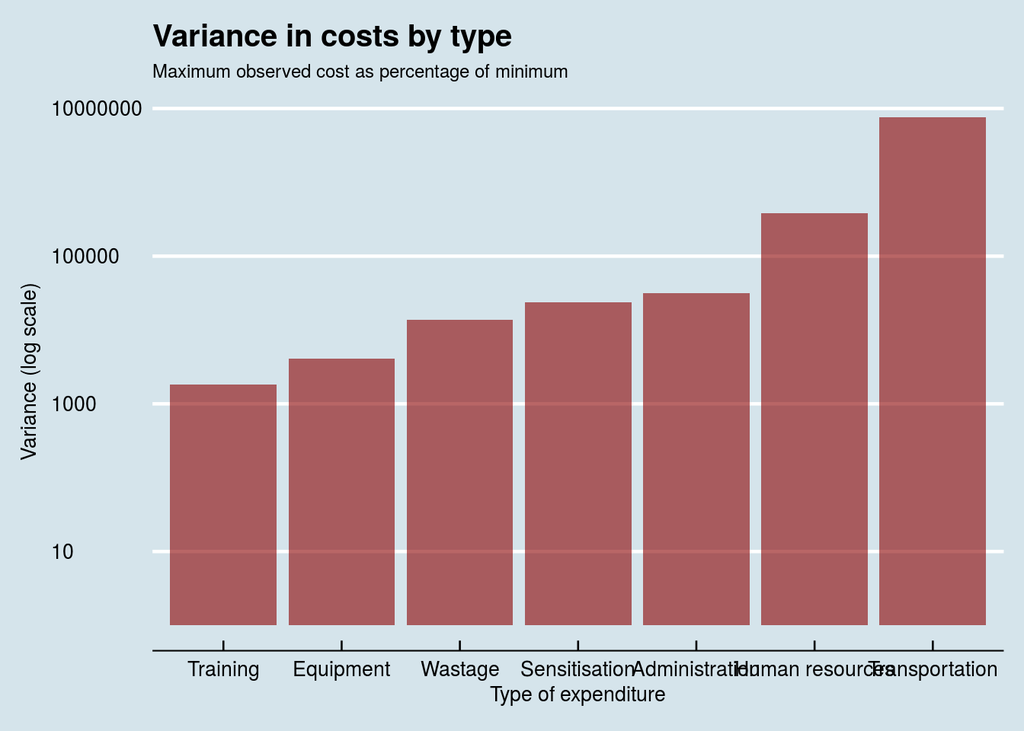

### Cost per dose by campaign type

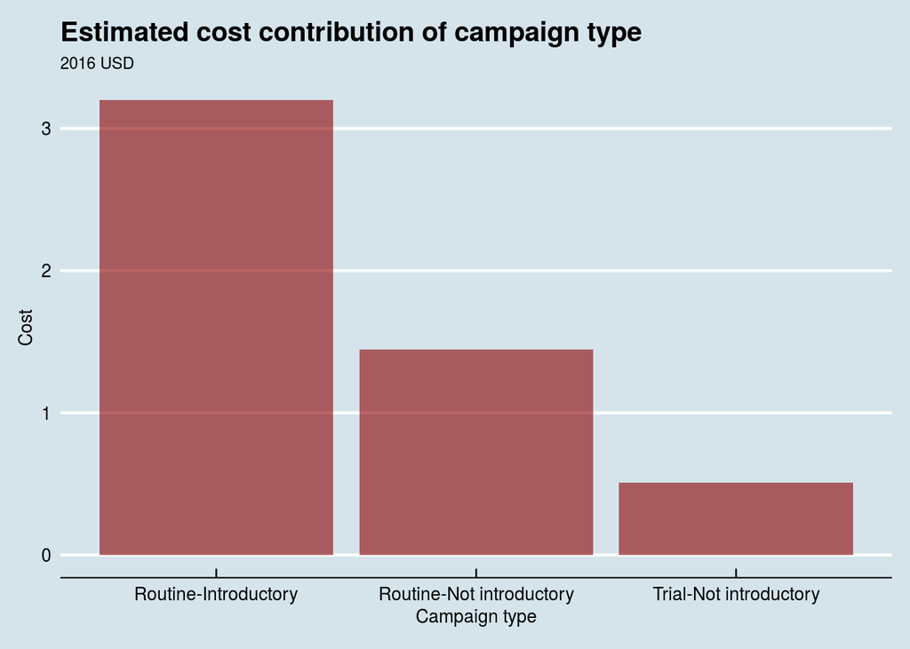

We run the same estimations for PPP-adjusted costs to produce the below.

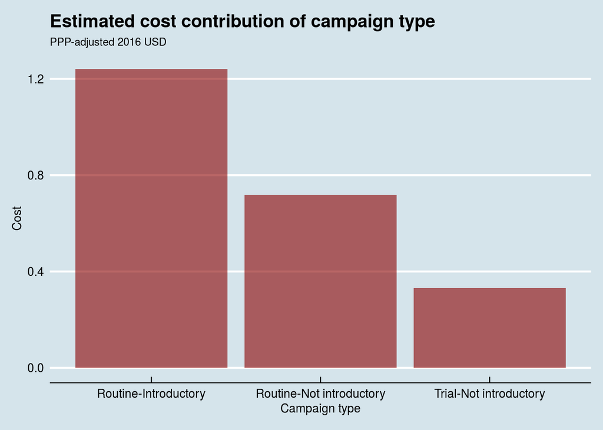

### Admnisistrative cost per campaign type

An examination of the average administrative cost per campaign type adds evidence to the above hypothesis.

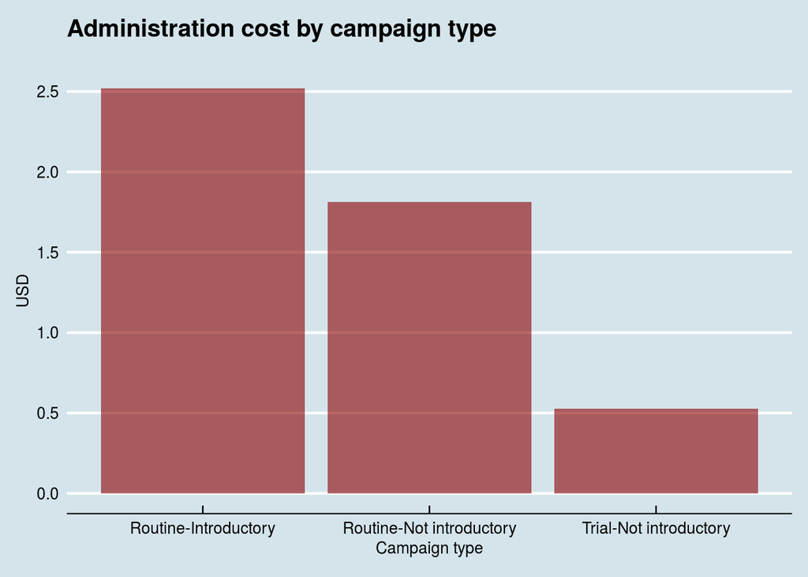

The below is the same data, but using PPP-adjusted costs.

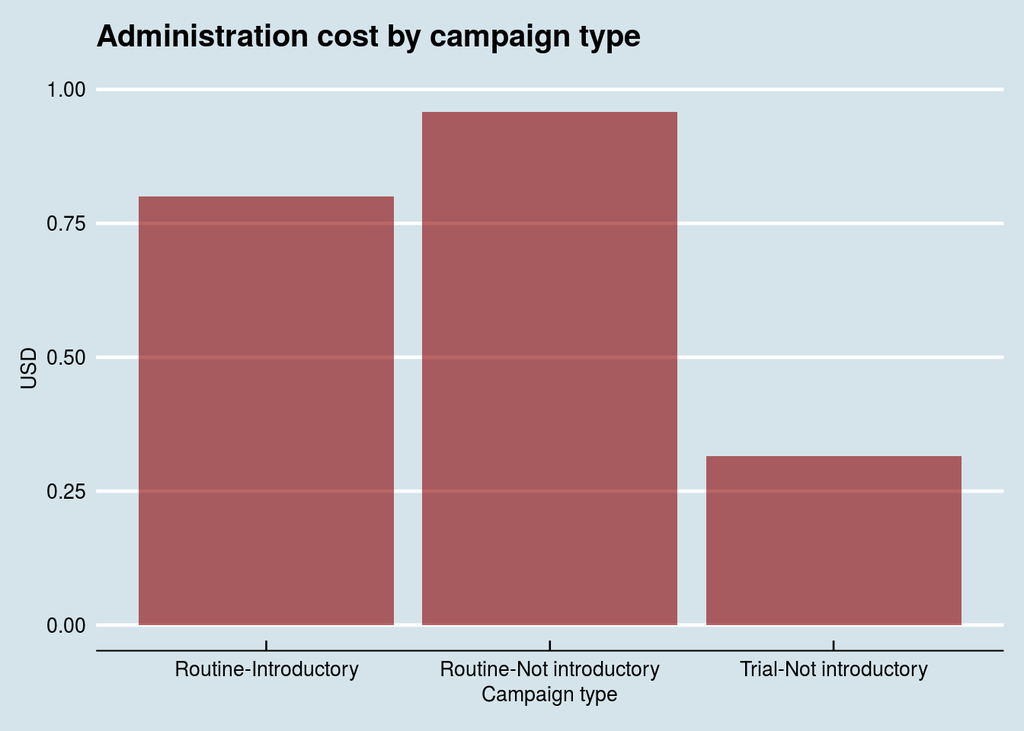

## Aggregate cost estimation

In order to estimate the average overall (non-vaccine) implementation cost per dose, we can run a Monte Carlo simulation. Performing 10,000 resamplings, we arrive at a distribution of the likely overall cost.

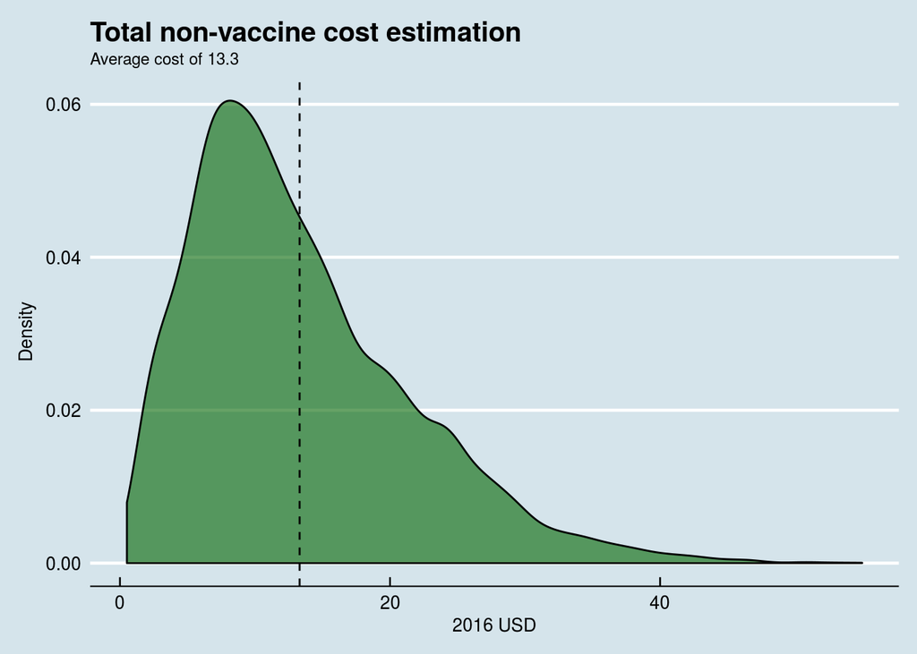

The below is the same visualization, using PPP-adjusted costs.

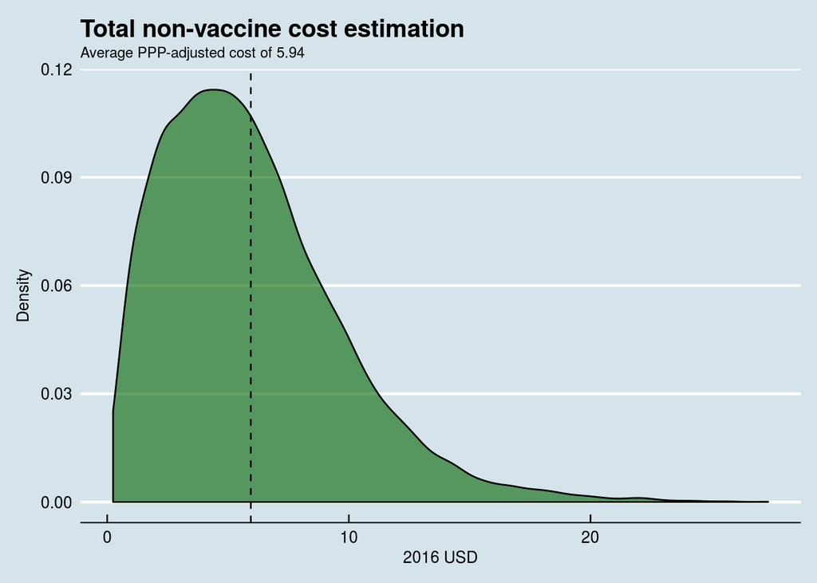

## Temporal dimensions of vaccine cost

An examination of item-specific costs over time shows no apparent secular trend. Accordingly, temporal data is explicitly ignored by our model.

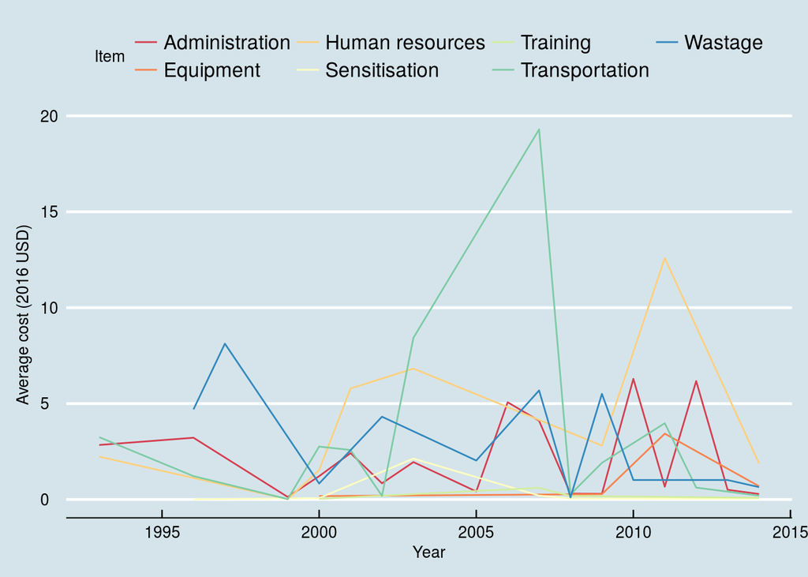

What follows is a table of the same data:

|  | Year | Item | Average cost |
| --- | --- | --- | --- |
| 1 | 1993 | Administration | 2.84 |
| 2 | 1993 | Human resources | 2.23 |
| 3 | 1993 | Transportation | 3.25 |
| 4 | 1996 | Administration | 3.22 |
| 5 | 1996 | Sensitisation | 0.01 |
| 6 | 1996 | Transportation | 1.22 |
| 7 | 1996 | Wastage | 4.7 |
| 8 | 1997 | Wastage | 8.12 |
| 9 | 1999 | Administration | 0.13 |
| 10 | 1999 | Human resources | 0.01 |

[output cut: 54 more lines]

## Geospatial determinants of vaccine cost

Not enough data on item-specific vaccine costs exist in the literature to form a model in which country itself is a stable predictor of cost. However, we can estimate geography’s *general* effect through generalized additive model.

Our model adjusts for item type, and uses a smoothed spatial surface to estimate the spatial effect of costs. The below map shows this effect, with the coloring of the surface reflecting the location-specific contribution to implementatoin cost in 2016 USD (per dose).

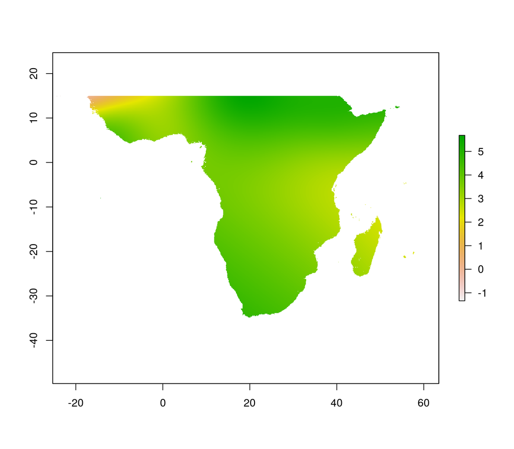

The below table shows model details.

```
Family: gaussian
Link function: identity

Formula:
cost ~ type + s(lng, lat, bs = "ad") + introduction

Parametric coefficients:
                    Estimate Std. Error t value    Pr(>|t|)
(Intercept)           0.7183     0.3886   1.849      0.0657 .
typeEquipment        -0.4675     0.7459  -0.627      0.5314
typeHuman resources   2.4445     0.5586   4.376 0.000017837 ***
typeSensitisation    -0.8649     0.7056  -1.226      0.2215
typeTraining         -0.9805     0.7027  -1.395      0.1642
typeTransportation    0.8360     0.5183   1.613      0.1081
typeWastage           0.8699     0.5534   1.572      0.1173
introductionTRUE      2.1444     0.4070   5.269 0.000000299 ***
---
Signif. codes:  0 '***' 0.001 '**' 0.01 '*' 0.05 '.' 0.1 ' ' 1

Approximate significance of smooth terms:
              edf Ref.df     F   p-value
te(lng,lat) 8.301  10.28 4.204 0.0000177 ***
---
Signif. codes:  0 '***' 0.001 '**' 0.01 '*' 0.05 '.' 0.1 ' ' 1

R-sq.(adj) =  0.268   Deviance explained = 31.1%
GCV = 7.9267  Scale est. = 7.4354    n = 263
```

## Integration with external data

GDP per capita (scraped from the World Bank’s data archives) over time was gathered for all countries from which any study was selected (see below chart).

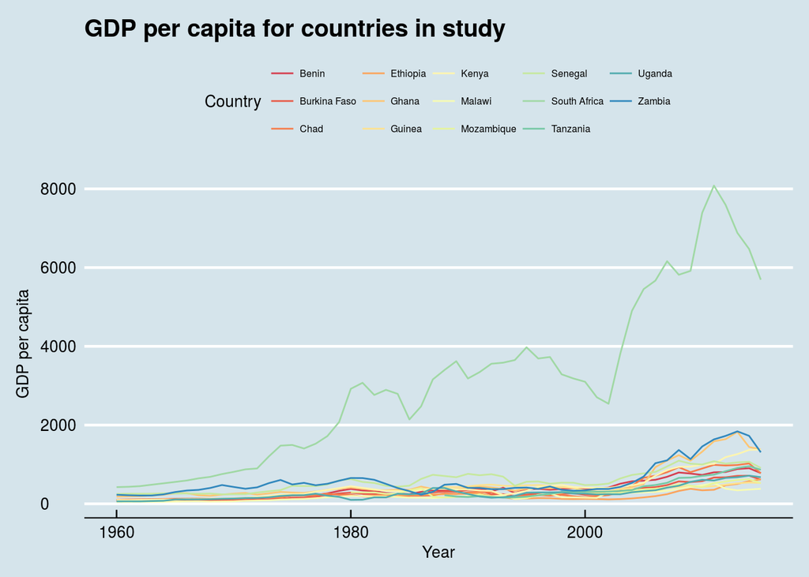

Data were paired for each country for the year in which the study was conducted. In the case of studies spanning multiple years, the year for which the currency value was reported in the study was used. The distribution of country-specific GDP per capita values for the final dataset can be visualized below.

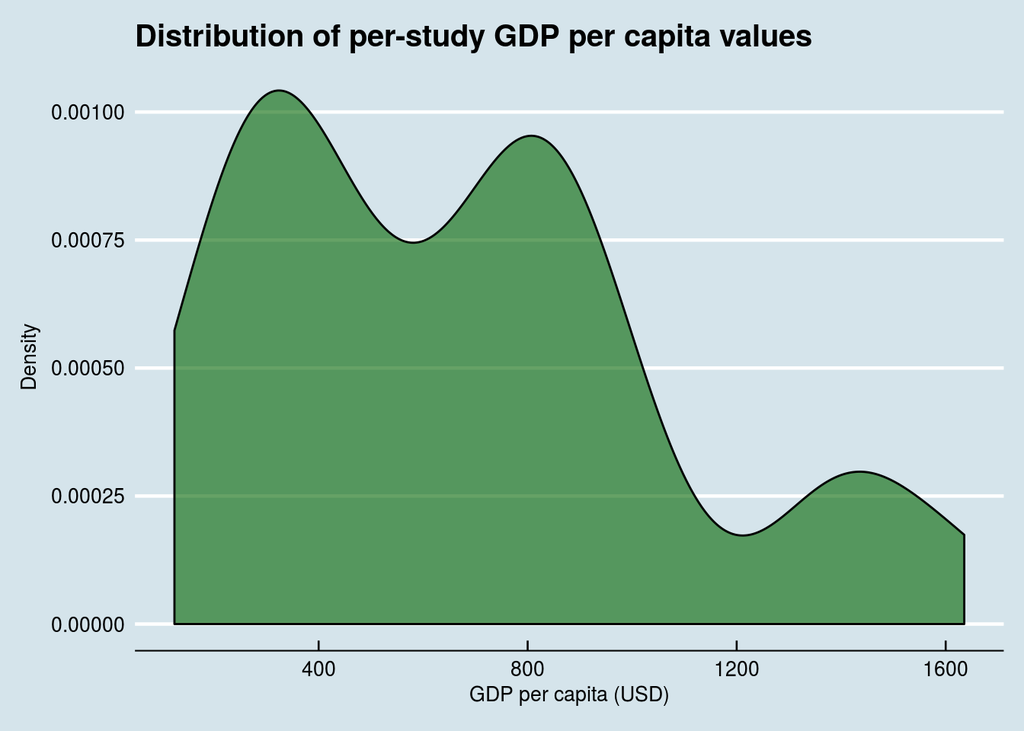

## Final model

The final model estimates the effect of both space (via smoothed latitude and longitude), weatlh (via GDP per capita), and programme type (routine vs. introduction) on the cost of non-vaccine immunisation programme costs. Estimation is carried out by modeling vaccine type, smoothed location, and GDP via a GAM.

The model’s coefficient estimates (excluding the smoothed bivariate spatial interpolation estimates, which are non-linear) are below.

|  | Item | Coefficient |
| --- | --- | --- |
| 1 | (Intercept) | 1.205 |
| 2 | Equipment | -0.248 |
| 3 | Human resources | 2.527 |
| 4 | Sensitisation | -0.746 |
| 5 | Training | -0.815 |
| 6 | Transportation | 0.862 |
| 7 | Wastage | 0.861 |
| 8 | Gdp | -0.001 |
| 9 | Introduction | 2.073 |

Model details are below:

```
Family: gaussian
Link function: identity

Formula:
cost ~ type + s(lng, lat, bs = "ad") + gdp + introduction

Parametric coefficients:
                      Estimate Std. Error t value   Pr(>|t|)
(Intercept)          1.2050208  0.5164564   2.333     0.0204 *
typeEquipment       -0.2475445  0.7637421  -0.324     0.7461
typeHuman resources  2.5272569  0.5617742   4.499 0.00001054 ***
typeSensitisation   -0.7458045  0.7111630  -1.049     0.2953
typeTraining        -0.8146409  0.7134385  -1.142     0.2546
typeTransportation   0.8617972  0.5188348   1.661     0.0980 .
typeWastage          0.8607631  0.5535504   1.555     0.1212
gdp                 -0.0007108  0.0004989  -1.425     0.1555
introductionTRUE     2.0725408  0.4089436   5.068 0.00000079 ***
---
Signif. codes:  0 '***' 0.001 '**' 0.01 '*' 0.05 '.' 0.1 ' ' 1

Approximate significance of smooth terms:
              edf Ref.df     F   p-value
te(lng,lat) 7.824  9.763 4.071 0.0000431 ***
---
Signif. codes:  0 '***' 0.001 '**' 0.01 '*' 0.05 '.' 0.1 ' ' 1

R-sq.(adj) =  0.267   Deviance explained = 31.1%
GCV = 7.9608  Scale est. = 7.4516    n = 263
```

## Projections for all of Africa

We can also use our model to project costs per dose for each item onto every Sub-Saharan African country. The below projections assume an “introductory” (as opposed to “routine”) campaign, with 2015 GDP and in 2015 currency.

The below map shows overall (all-item) non-vaccine costs across Africa.

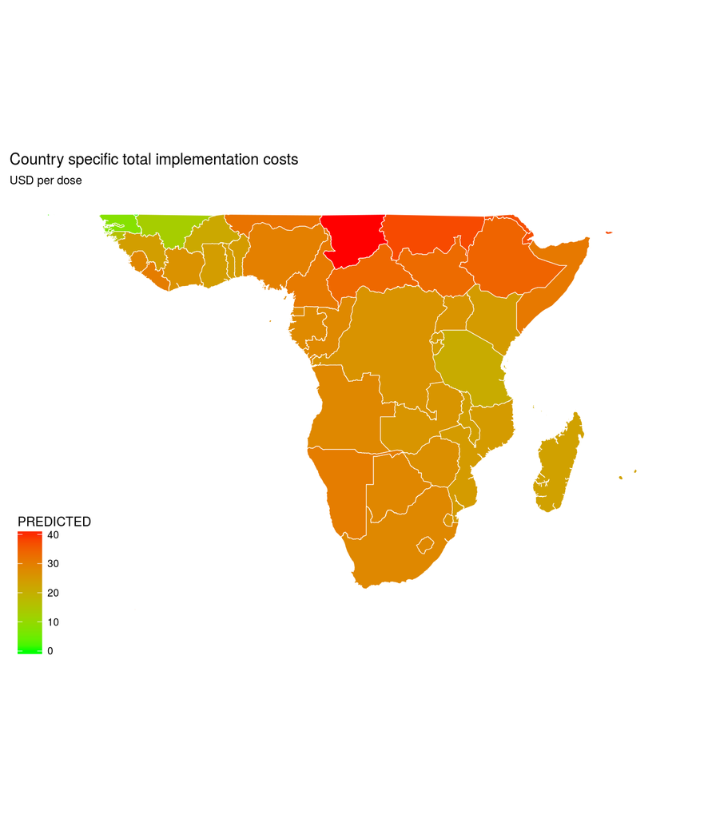

# Discussion

## Main findings

The principal contribution of this study is the generation of an estimate, based purely on costs in a similar context, of the non-vaccine immunisation programme implementation costs for the roll-out of a Malaria vaccine across Africa. To the authors’ knowledge, this is the first study to attempt such a quantification.

## Limitations

This study, and its results, are not without limitations. Chief among them is the small sample size from which estimates were modeled (and, by extension, the corresponding wide confidence intervals). Secondly, lack of comparability of cost types makes the itemizing of costs a somewhat futile exercise. Third, this study assumes that administration of the roll-out of a malaria vaccine will be similar to that of other vaccines (a possible, but by no means certain, scenario). Fourth, we do not delve into dosage, age, or coverage issues. Finally, this study is narrow in scope, only looking at vaccine studies in Africa, and ignoring other areas where Malaria is endemic (Southeast Asia, Central and South America, etc.).

## Further research

Further research is needed, particularly into those factors which determine vaccine programme cost. A particular challenge, and one encountered in this study at multiple points, is the lack of standardisation (and by extension, comparability) among studies.

For example, whereas in some studies “administration” included personnel (ie, “human resources” costs), others did not. Some studies published wages and salaries, but not the amount of person-time allocated to the programme. The distinction between fixed and variable costs appeared in fewer than half of studies, and many studies made no mention of whether or how they attempted to quantify “in-kind” costs.

To address this issue, we propose to devise and publish (as a separate paper) a “template” of best practices for reporting vaccine cost studies.

# Details

This work was carried out by Elisa Sicuri and Joe Brew, in collaboration with GSK. A debt of gratitude is owed to Celine Aerts, who helped with data collection.

All analysis was carried out in the R programming language in R version 3.4.1 (2017-06-30) on a x86_64, linux-gnu system.

# Appendix

## Final selected papers

| Title | Year | Affiliation | All authors | Url |
| --- | --- | --- | --- | --- |
| The cost of integrating hepatitis B virus vaccine into national immunization programmes: a case study from Addis Ababa. | 2000 | Department of Biological Sciences, University of Warwick, Coventry, UK. jedmunds@phls.nhs.uk | W Edmunds, A Dejene, Y Mekonnen, M Haile, W Alemnu, D Nokes | http://www.ncbi.nlm.nih.gov/pubmed/?term=11124244 |
| Comparison of cost-effectiveness of preventive and reactive mass immunization campaigns against meningococcal meningitis in West Africa: a theoretical modeling analysis. | 2001 | Association pour l’Aide à la Médecine Préventive, 28 rue du Docteur Roux, 75724 Cedex 15, Paris, France. iparent@compuserve.com | I Parent du Châtelet, B D Gessner, A da Silva | http://www.ncbi.nlm.nih.gov/pubmed/?term=11348706 |
| [Vaccination against viral hepatitis B for public health personnel: the case of the National Fund of Social Security]. | 2002 | Polyclinique El Khadra CNSS, Tunis, Tunisie. | N Saadallah, N Jaoua, A Ben Hamida, T Najjar, B Zouari | http://www.ncbi.nlm.nih.gov/pubmed/?term=11892442 |
| Cost-effectiveness of three different vaccination strategies against measles in Zambian children. | 2003 | Centers for Disease Control and Prevention, National Immunization Program, 1600 Clifton Road, Mailstop E-61, Atlanta, GA 30333, USA. gdayan@cdc.gov | Gustavo H Dayan, Lisa Cairns, Nalinee Sangrujee, Anne Mtonga, Van Nguyen, Peter Strebel | http://www.ncbi.nlm.nih.gov/pubmed/?term=14670330 |
| Impact of mass measles campaigns among children less than 5 years old in Uganda. | 2003 | Uganda Virus Research Institute, Ministry of Health, Entebbe, Uganda. mnanyunja@who.imul.com | Miriam Nanyunja, Rosamund F Lewis, Issa Makumbi, Rachel Seruyange, Eva Kabwongera, Possy Mugyenyi, Ambrose Talisuna | http://www.ncbi.nlm.nih.gov/pubmed/?term=12721893 |
| Economic analysis of the 1996-1997 mass measles immunization campaigns in South Africa. | 2004 | Global Immunization Division, National Immunization Program, Centers for Disease Control and Prevention, 1600 Clifton Road, MS E-05, Atlanta, GA 30333, USA. auzicanin@cdc.gov | Amra Uzicanin, Fangjun Zhou, Rudi Eggers, Elize Webb, Peter Strebel | http://www.ncbi.nlm.nih.gov/pubmed/?term=15308367 |
| [Microeconomic evaluation of a mass preventive immunisation campaign against meningococcal meningitis and yellow fever in Senegal in 1997]. | 2004 | Association pour l’aide à la médecine préventive, 25, rue du Dr Roux, 75724 Paris, France. aldasilva@compuserve.com | Alfred da Silva, Isabelle Parent du Châtelet, Abou Beckr Gaye, Jean-Pierre Dompnier, Ibrahima Seck | http://www.ncbi.nlm.nih.gov/pubmed/?term=15047438 |
| Feasibility of a mass vaccination campaign using a two-dose oral cholera vaccine in an urban cholera-endemic setting in Mozambique. | 2005 | Epicentre, Paris, France. philippe.cavailler@epicentre.msf.org | Philippe Cavailler, Marcelino Lucas, Valerie Perroud, Margaret McChesney, Sonia Ampuero, Philippe J Guérin, Dominique Legros, Thomas Nierle, Claude Mahoudeau, Bruno Lab, Pierre Kahozi, Jacqueline L De… | http://www.ncbi.nlm.nih.gov/pubmed/?term=S0264-410X(05)01042-X |
| Review of the cost effectiveness of immunisation strategies for the control of epidemic meningococcal meningitis. | 2005 | Division on International Epidemiology and Population Studies, Fogarty Internatonal Center, National Institutes of Health, Building 16, 16 Center Drive, Bethesda, MD 20892-6705, USA. millermark@nih.go… | Mark A Miller, Cathryn K Shahab | http://www.ncbi.nlm.nih.gov/pubmed/?term=2344 |
| The cost-effectiveness of introducing hepatitis B vaccine into infant immunization services in Mozambique. | 2005 | Department of Vaccines and Biologicals, World Health Organization, 20 Avenue Appia, 1211 Geneva 27, Switzerland. Griffithsu@who.int | Ulla K Griffiths, Guy Hutton, Eva Das Dores Pascoal | http://www.ncbi.nlm.nih.gov/pubmed/?term=20/1/50 |
| Predicting the cost-effectiveness of introducing a pre-erythrocytic malaria vaccine into the expanded program on immunization in Tanzania. | 2006 | Swiss Tropical Institute, Basel, Switzerland. fabrizio.tediosi@unibas.ch | Fabrizio Tediosi, Guy Hutton, Nicolas Maire, Thomas A Smith, Amanda Ross, Marcel Tanner | http://www.ncbi.nlm.nih.gov/pubmed/?term=75/2_suppl/131 |
| The costs of introducing a malaria vaccine through the expanded program on immunization in Tanzania. | 2006 | Swiss Tropical Institute, Basel, Switzerland. guy.hutton@unibas.ch | Guy Hutton, Fabrizio Tediosi | http://www.ncbi.nlm.nih.gov/pubmed/?term=75/2_suppl/119 |
| Economic evaluation of hepatitis B vaccination in low-income countries: using cost-effectiveness affordability curves. | 2007 | Program in Health Decision Science, Health Policy and Management Department, Harvard School of Public Health, Boston, MA 02115, USA. | Sun-Young Kim, Joshua A Salomon, Sue J Goldie | http://www.ncbi.nlm.nih.gov/pubmed/?term=S0042-96862007001100009 |
| Economic evaluation of delivering Haemophilus influenzae type b vaccine in routine immunization services in Kenya. | 2007 | Kenya Medical Research Institute (KEMRI)/Wellcome Trust. Nairobi, Kenya. | Angela Oloo Akumu, Mike English, J Anthony G Scott, Ulla K Griffiths | http://www.ncbi.nlm.nih.gov/pubmed/?term=S0042-96862007000700008 |
| An economic evaluation of thermostable vaccines in Cambodia, Ghana and Bangladesh. | 2007 | ann@levinmorgan.com | Ann Levin, Carol Levin, Debra Kristensen, Dipika Matthias | http://www.ncbi.nlm.nih.gov/pubmed/?term=S0264-410X(07)00758-X |
| Incremental system costs of introducing combined DTwP-hepatitis B-Hib vaccine into national immunization services in Ethiopia. | 2009 | Hib Initiative, Health Policy Unit, London School of Hygiene and Tropical Medicine, Keppel Street, London WC1E 7HT, United Kingdom. ulla.griffiths@lshtm.ac.uk | Ulla K Griffiths, Viola S Korczak, Dereje Ayalew, Asnakew Yigzaw | http://www.ncbi.nlm.nih.gov/pubmed/?term=S0264-410X(08)01762-3 |
| Incremental costs of introducing jet injection technology for delivery of routine childhood vaccinations: comparative analysis from Brazil, India, and South Africa. | 2010 | London School of Hygiene and Tropical Medicine, Tavistock Place, London WC1H 9SH, UK. ulla.griffiths@lshtm.ac.uk | Ulla K Griffiths, Andreia C Santos, Neeti Nundy, Erica Jacoby, Dipika Matthias | http://www.ncbi.nlm.nih.gov/pubmed/?term=S0264-410X(10)01672-5 |
| Economic evaluation of pneumococcal conjugate vaccination in The Gambia. | 2010 | Department of Health Policy and Management, Harvard School of Public Health, Center for Health Decision Science, Boston, MA, USA. sykim@hsph.harvard.edu | Sun-Young Kim, Gene Lee, Sue J Goldie | http://www.ncbi.nlm.nih.gov/pubmed/?term=1471-2334-10-260 |
| The cost-effectiveness of rotavirus vaccination in Malawi. | 2010 | Johns Hopkins University School of Medicine, Baltimore, Maryland 21287, USA. sberry8@jhmi.edu | Stephen A Berry, Benjamin Johns, Chuck Shih, Andrea A Berry, Damian G Walker | http://www.ncbi.nlm.nih.gov/pubmed/?term=10.1086/653578 |
| Cost-effectiveness of the introduction of a pre-erythrocytic malaria vaccine into the expanded program on immunization in sub-Saharan Africa: analysis of uncertainties using a stochastic individual-ba… | 2011 | Swiss Tropical and Public Health Institute, Basel, Switzerland. | Nicolas Maire, Samuel D Shillcutt, Damian G Walker, Fabrizio Tediosi, Thomas A Smith | http://www.ncbi.nlm.nih.gov/pubmed/?term=S1098-3015(11)01526-9 |
| Cost-effectiveness analysis of an additional birth dose of Hepatitis B vaccine to prevent perinatal transmission in a medical setting in Mozambique. | 2012 | London School of Economics and Political Science, London WC2A 2AE, United Kingdom. Corinna.Klingler@med.uni-muenchen.de | Corinna Klingler, Andrea I Thoumi, Vinod S Mrithinjayam | http://www.ncbi.nlm.nih.gov/pubmed/?term=S0264-410X(12)01173-5 |
| Evaluation of cost-effectiveness of live oral pentavalent reassortant rotavirus vaccine introduction in Ghana. | 2012 | Departments of Ecology and Evolutionary Biology, Molecular Biology and Woodrow Wilson School of Public and International Affairs, Princeton University, Princeton, NJ 08544, United States. | Collette Abbott, Benjamin Tiede, George Armah, Adel Mahmoud | http://www.ncbi.nlm.nih.gov/pubmed/?term=S0264-410X(12)00114-4 |
| Delivery cost of human papillomavirus vaccination of young adolescent girls in Peru, Uganda and Viet Nam. | 2013 | Department of Global Health, University of Washington, Seattle, WA 98104, USA. clevin@uw.edu | Carol E Levin, Hoang Van Minh, John Odaga, Swampa Sarit Rout, Diep Nguyen Thi Ngoc, Lysander Menezes, Maria Ana Mendoza Araujo, D Scott LaMontagne | http://www.ncbi.nlm.nih.gov/pubmed/?term=10.2471/BLT.12.113837 |
| The benefits of redesigning Benin’s vaccine supply chain. | 2014 | Pittsburgh Supercomputing Center (PSC), Pittsburgh, PA, USA. | Shawn T Brown, Benjamin Schreiber, Brigid E Cakouros, Angela R Wateska, Hamadou M Dicko, Diana L Connor, Philippe Jaillard, Mercy Mvundura, Bryan A Norman, Carol Levin, Jayant Rajgopal, Mélanie Avella… | http://www.ncbi.nlm.nih.gov/pubmed/?term=24814550 |
| Economic benefits of keeping vaccines at ambient temperature during mass vaccination: the case of meningitis A vaccine in Chad. | 2014 | Expanded Programme on Immunization Plus, World Health Organization, avenue Appia 20, 1211 Geneva 27, Switzerland . | Patrick Lydon, Simona Zipursky, Carole Tevi-Benissan, Mamoudou Harouna Djingarey, Placide Gbedonou, Brahim Oumar Youssouf, Michel Zaffran | http://www.ncbi.nlm.nih.gov/pubmed/?term=10.2471/BLT.13.123471 |
| Cost-effectiveness of a potential group B streptococcal vaccine program for pregnant women in South Africa. | 2014 | Division of Management, Policy and Community Health, University of Texas School of Public Health, San Antonio, TX, USA. Electronic address: Sun-Young.Kim@uth.tmc.edu. | Sun-Young Kim, Louise B Russell, Jeehyun Park, Jennifer R Verani, Shabir A Madhi, Clare L Cutland, Stephanie J Schrag, Anushua Sinha | http://www.ncbi.nlm.nih.gov/pubmed/?term=24530145 |
| Mass vaccination with a new, less expensive oral cholera vaccine using public health infrastructure in India: the Odisha model. | 2014 | Regional Medical Research Center, Bhubaneswar, Odisha, India. | Shantanu K Kar, Binod Sah, Bikash Patnaik, Yang Hee Kim, Anna S Kerketta, Sunheang Shin, Shyam Bandhu Rath, Mohammad Ali, Vittal Mogasale, Hemant K Khuntia, Anuj Bhattachan, Young Ae You, Mahesh K Pur… | http://www.ncbi.nlm.nih.gov/pubmed/?term=10.1371/journal.pntd.0002629 |
| Costs of vaccine delivery in the Gambia before and after, pentavalent and pneumococcal conjugate vaccine introductions. | 2014 | MRC, Gambia Unit, The Gambia; Gambia Government, The Gambia; London School of Hygiene and Tropical Medicine, UK. Electronic address: effuau@gmail.com. | E Usuf, G Mackenzie, Y Lowe-Jallow, B Boye, D Atherly, C Suraratdecha, U K Griffiths | http://www.ncbi.nlm.nih.gov/pubmed/?term=24503271 |
| Potential cost-effectiveness of a new infant tuberculosis vaccine in South Africa–implications for clinical trials: a decision analysis. | 2014 | Respiratory Epidemiology and Clinical Research Unit, Montreal Chest Institute, Montreal, Quebec, Canada. | Jared B Ditkowsky, Kevin Schwartzman | http://www.ncbi.nlm.nih.gov/pubmed/?term=10.1371/journal.pone.0083526 |
| What have we learned on costs and financing of routine immunization from the comprehensive multi-year plans in GAVI eligible countries? | 2015 | Bill & Melinda Gates Foundation, Vaccine Delivery, 4929 Chevy Chase Blvd, Chevy Chase, MD 20815, United States. Electronic address: logan.brenzel@gatesfoundation.org. | Logan Brenzel | http://www.ncbi.nlm.nih.gov/pubmed/?term=S0264-410X(15)00022-5 |
| Mapping financial flows for immunisation in Uganda 2009/10 and 2010/11: New insights for methodologies and policy. | 2015 | Centre for Economic Governance and AIDS in Africa (CEGAA), Cape Town, South Africa. Electronic address: guthriehealthfinancingconsult@gmail.com. | Teresa Guthrie, Charlotte Zikusooka, Brendan Kwesiga, Christabel Abewe, Stephen Lagony, Carl Schutte, Edmore Marinda, Kerrin Humphreys, Katlego Motlogelwa, Zipozihle Chuma Nombewu, Logan Brenzel, Anth… | http://www.ncbi.nlm.nih.gov/pubmed/?term=S0264-410X(14)01708-3 |
| Determinants of routine immunization costing in Benin and Ghana in 2011. | 2015 | Agence de Médecine Préventive (AMP), Ferney-Voltaire, France. | Césaire Damien Ahanhanzo, Xiao Xian Huang, Jean-Bernard Le Gargasson, Justin Sossou, Frank Nyonator, Anais Colombini, Bradford D Gessner | http://www.ncbi.nlm.nih.gov/pubmed/?term=S0264-410X(14)01724-1 |
| Cost analysis of routine immunisation in Zambia. | 2015 | Strategic Development Consultants, South Africa. Electronic address: carl.schutte@sdc.co.za. | Carl Schütte, Collins Chansa, Edmore Marinda, Teresa A Guthrie, Stanley Banda, Zipozihle Nombewu, Katlego Motlogelwa, Marita Lervik, Logan Brenzel, Anthony Kinghorn | http://www.ncbi.nlm.nih.gov/pubmed/?term=S0264-410X(14)01693-4 |
| Costs of routine immunization and the introduction of new and underutilized vaccines in Ghana. | 2015 | Agence de Médecine Préventive, Paris, France. Electronic address: jblegargasson@aamp.org. | Jean-Bernard Le Gargasson, Frank K Nyonator, Moses Adibo, Bradford D Gessner, Anaïs Colombini | http://www.ncbi.nlm.nih.gov/pubmed/?term=S0264-410X(15)00030-4 |
| Cost-effectiveness analysis of the introduction of the pneumococcal conjugate vaccine (PCV-13) in the Egyptian national immunization program, 2013. | 2015 | Expanded Program on Immunization, Ministry of Health, Egypt. Electronic address: sibakmohammed@gmail.com. | Mohammed Sibak, Ibrahim Moussa, Nasr El-Tantawy, Shaza Badr, Irtaza Chaudhri, Essam Allam, Louise Baxter, Saiyed Abo Freikha, Céline Hoestlandt, Carlos Lara, Rana Hajjeh, Aline Munier | http://www.ncbi.nlm.nih.gov/pubmed/?term=S0264-410X(14)01697-1 |
| Cost-effectiveness of rotavirus vaccination in Kenya and Uganda. | 2015 | P.O. Box 293-20203, Londiani, Kenya. | Charles Sigei, John Odaga, Mercy Mvundura, Yvette Madrid, Andrew David Clark, Dominic Mutie, Peter Kamau, Amina Ishmael Mungai, Terry Watiri, Zipporah Gatheru, Joyce Charo, Bonface Osano, Bakari Mwiny… | http://www.ncbi.nlm.nih.gov/pubmed/?term=S0264-410X(15)00027-4 |
| One size does not fit all: The impact of primary vaccine container size on vaccine distribution and delivery. | 2015 | Public Health Computational and Operations Research (PHICOR), Pittsburgh PA (formerly) and Baltimore MD (currently), United States; Pittsburgh Supercomputing Center (PSC), Carnegie Mellon University, … | Leila A Haidari, Brian Wahl, Shawn T Brown, Lois Privor-Dumm, Cecily Wallman-Stokes, Katie Gorham, Diana L Connor, Angela R Wateska, Benjamin Schreiber, Hamadou Dicko, Philippe Jaillard, Melanie Avell… | http://www.ncbi.nlm.nih.gov/pubmed/?term=25889160 |
| Economic evaluation of typhoid vaccination in a prolonged typhoid outbreak setting: the case of Kasese district in Uganda. | 2015 | Office of Science and Integrated Programs, Centers for Disease Control and Prevention, Atlanta, GA, United States; IHRC Inc, Atlanta, GA, United States. Electronic address: vnn9@cdc.gov. | Cristina Carias, Maroya Spalding Walters, Edward Wefula, Kashmira A Date, David L Swerdlow, Maya Vijayaraghavan, Eric Mintz | http://www.ncbi.nlm.nih.gov/pubmed/?term=25712333 |
| The costs of delivering human papillomavirus vaccination to Grade 4 learners in KwaZulu-Natal, South Africa. | 2016 | Health Outcomes Research Unit, Discipline of Public Health Medicine, College of Health Sciences, Nelson R Mandela School of Medicine, University of KwaZulu-Natal, Durban, South Africa. moodleyi15@ukzn… | Indres Moodley, Nerisha Tathiah, Ben Sartorius | http://www.ncbi.nlm.nih.gov/pubmed/?term=27138671 |
| Projected economic evaluation of the national implementation of a hypothetical HIV vaccination program among adolescents in South Africa, 2012. | 2016 | Perinatal HIV Research Unit, Faculty of Health Sciences University of the Witwatersrand, PO Box 114, Diepkloof 1864, Johannesburg, South Africa. nishila.moodley@gmail.com. | Nishila Moodley, Glenda Gray, Melanie Bertram | http://www.ncbi.nlm.nih.gov/pubmed/?term=10.1186/s12889-016-2959-3 |
| The Case for Adolescent HIV Vaccination in South Africa: A Cost-Effectiveness Analysis. | 2016 | From the Perinatal HIV Research Unit, Faculty of Health Sciences, University of the Witwatersrand, Johannesburg (NM, GG); South African HVTN AIDS Vaccine Early Stage Investigator Program (SHAPe) (NM);… | Nishila Moodley, Glenda Gray, Melanie Bertram | http://www.ncbi.nlm.nih.gov/pubmed/?term=10.1097/MD.0000000000002528 |

## Raw itemized data

| DISEASE | DOSES | TYPE | SOURCE | LINK | YEAR | COUNTRY | COST | COUNTRY NAME | GDP | TRIAL | INTRODUCTION | CURRENCY | EXCHANGE_RATE | NEW_COUNTRY | PPP | PPP_ADJUSTMENT | COST_PPP |
| --- | --- | --- | --- | --- | --- | --- | --- | --- | --- | --- | --- | --- | --- | --- | --- | --- | --- |
| MULTIPLE | 1 | Wastage | An economic evaluation of thermostable vaccines in Cambodia, Ghana and Bangladesh. | http://www.sciencedirect.com/science/article/pii/S0264410X0700758X | 2002 | Multiple | 0.4062127 | NA | 411.9591 | FALSE | FALSE | USD | 1.0000000 | United States | 1.0000000 | 1.000000 | 0.4062127 |
| MULTIPLE | 1 | Transportation | An economic evaluation of thermostable vaccines in Cambodia, Ghana and Bangladesh. | http://www.sciencedirect.com/science/article/pii/S0264410X0700758X | 2002 | Ghana | 0.0401940 | Ghana | 311.6168 | FALSE | FALSE | GHS | 0.9312843 | Ghana | 0.1276647 | 7.294769 | 0.0055100 |
| MULTIPLE | 1 | Transportation | An economic evaluation of thermostable vaccines in Cambodia, Ghana and Bangladesh. | http://www.sciencedirect.com/science/article/pii/S0264410X0700758X | 2002 | Ghana | 0.1205820 | Ghana | 311.6168 | FALSE | FALSE | GHS | 0.9312843 | Ghana | 0.1276647 | 7.294769 | 0.0165299 |
| MEASLES | 1 | Wastage | An economic evaluation of thermostable vaccines in Cambodia, Ghana and Bangladesh. | http://www.sciencedirect.com/science/article/pii/S0264410X0700758X | 2002 | Ghana | 6.4994026 | Ghana | 311.6168 | FALSE | FALSE | GHS | 0.9312843 | Ghana | 0.1276647 | 7.294769 | 0.8909675 |
| MEASLES | 1 | Wastage | An economic evaluation of thermostable vaccines in Cambodia, Ghana and Bangladesh. | http://www.sciencedirect.com/science/article/pii/S0264410X0700758X | 2002 | Ghana | 5.0776583 | Ghana | 311.6168 | FALSE | FALSE | GHS | 0.9312843 | Ghana | 0.1276647 | 7.294769 | 0.6960684 |
| MULTIPLE | 1 | Human resources | Cost analysis of routine immunisation in Zambia | http://www.sciencedirect.com.sire.ub.edu/science/article/pii/S0264410X14016934 | 2011 | Zambia | 12.3691756 | Zambia | 1635.5473 | FALSE | FALSE | ZMW | 5.3974108 | Zambia | 2.3783803 | 2.269364 | 5.4505031 |
| MULTIPLE | 1 | Equipment | Cost analysis of routine immunisation in Zambia | http://www.sciencedirect.com.sire.ub.edu/science/article/pii/S0264410X14016934 | 2011 | Zambia | 3.4324970 | Zambia | 1635.5473 | FALSE | FALSE | ZMW | 5.3974108 | Zambia | 2.3783803 | 2.269364 | 1.5125370 |
| MULTIPLE | 1 | Administration | Cost analysis of routine immunisation in Zambia | http://www.sciencedirect.com.sire.ub.edu/science/article/pii/S0264410X14016934 | 2011 | Zambia | 0.6702509 | Zambia | 1635.5473 | FALSE | FALSE | ZMW | 5.3974108 | Zambia | 2.3783803 | 2.269364 | 0.2953475 |
| MULTIPLE | 1 | Transportation | Cost analysis of routine immunisation in Zambia | http://www.sciencedirect.com.sire.ub.edu/science/article/pii/S0264410X14016934 | 2011 | Zambia | 1.4826762 | Zambia | 1635.5473 | FALSE | FALSE | ZMW | 5.3974108 | Zambia | 2.3783803 | 2.269364 | 0.6533444 |
| HEPATITIS B | 1 | Transportation | Cost-effectiveness analysis of an additional birth dose of Hepatitis B vaccine to prevent perinatal transmission in a medical setting in Mozambique. | http://www.sciencedirect.com/science/article/pii/S0264410X12011735 | 2008 | Mozambique | 0.4142150 | Mozambique | 499.8871 | FALSE | FALSE | MZN | 24.1367352 | Mozambique | 14.8415955 | 1.626290 | 0.2546994 |
| HEPATITIS B | 1 | Sensitisation | Cost-effectiveness analysis of an additional birth dose of Hepatitis B vaccine to prevent perinatal transmission in a medical setting in Mozambique. | http://www.sciencedirect.com/science/article/pii/S0264410X12011735 | 2008 | Mozambique | 0.0506574 | Mozambique | 499.8871 | FALSE | FALSE | MZN | 24.1367352 | Mozambique | 14.8415955 | 1.626290 | 0.0311490 |
| HEPATITIS B | 1 | Training | Cost-effectiveness analysis of an additional birth dose of Hepatitis B vaccine to prevent perinatal transmission in a medical setting in Mozambique. | http://www.sciencedirect.com/science/article/pii/S0264410X12011735 | 2008 | Mozambique | 0.3315511 | Mozambique | 499.8871 | FALSE | FALSE | MZN | 24.1367352 | Mozambique | 14.8415955 | 1.626290 | 0.2038696 |
| PNEUMOCOCCAL | 1 | Administration | Cost-effectiveness analysis of the introduction of the pneumococcal conjugate vaccine (PCV-13) in the Egyptian national immunization program, 2013 | http://www.sciencedirect.com.sire.ub.edu/science/article/pii/S0264410X14016971 | 2013 | Egypt | 0.6093190 | NA | 882.6386 | FALSE | TRUE | EGP | 6.8362274 | Egypt, Arab Rep. | 2.0234302 | 3.378534 | 0.1803501 |
| PNEUMOCOCCAL | 1 | Administration | Cost-effectiveness analysis of the introduction of the pneumococcal conjugate vaccine (PCV-13) in the Egyptian national immunization program, 2013 | http://www.sciencedirect.com.sire.ub.edu/science/article/pii/S0264410X14016971 | 2013 | Egypt | 0.4062127 | NA | 882.6386 | FALSE | TRUE | EGP | 6.8362274 | Egypt, Arab Rep. | 2.0234302 | 3.378534 | 0.1202334 |
| PNEUMOCOCCAL | 1 | Wastage | Cost-effectiveness analysis of the introduction of the pneumococcal conjugate vaccine (PCV-13) in the Egyptian national immunization program, 2013 | http://www.sciencedirect.com.sire.ub.edu/science/article/pii/S0264410X14016971 | 2013 | Egypt | 1.0155317 | NA | 882.6386 | FALSE | TRUE | EGP | 6.8362274 | Egypt, Arab Rep. | 2.0234302 | 3.378534 | 0.3005835 |
| GROUP B STREPTOCOCCUS | 1 | Wastage | Cost-effectiveness of a potential group B streptococcal vaccine program for pregnant women in South Africa | http://www.sciencedirect.com.sire.ub.edu/science/article/pii/S0264410X14001145 | 2010 | South africa | 1.0155317 | NA | 732.9536 | FALSE | FALSE | ZAR | 7.3181060 | South Africa | 4.5737362 | 1.600028 | 0.6346962 |
| GROUP B STREPTOCOCCUS | 1 | Administration | Cost-effectiveness of a potential group B streptococcal vaccine program for pregnant women in South Africa | http://www.sciencedirect.com.sire.ub.edu/science/article/pii/S0264410X14001145 | 2010 | South africa | 6.2897260 | NA | 732.9536 | FALSE | FALSE | ZAR | 7.3181060 | South Africa | 4.5737362 | 1.600028 | 3.9310099 |
| ROTAVIRUS | 1 | Transportation | Cost-effectiveness of rotavirus vaccination in Kenya and Uganda | http://www.sciencedirect.com.sire.ub.edu/science/article/pii/S0264410X15000274 | 2000 | Kenya and uganda | 0.6093190 | NA | 369.7009 | FALSE | FALSE | KES | 76.1825683 | Kenya | 18.2096097 | 4.183646 | 0.1456430 |
| ROTAVIRUS | 1 | Administration | Cost-effectiveness of rotavirus vaccination in Kenya and Uganda | http://www.sciencedirect.com.sire.ub.edu/science/article/pii/S0264410X15000274 | 2000 | Kenya and uganda | 0.4062127 | NA | 369.7009 | FALSE | FALSE | KES | 76.1825683 | Kenya | 18.2096097 | 4.183646 | 0.0970954 |
| ROTAVIRUS | 1 | Wastage | Cost-effectiveness of rotavirus vaccination in Kenya and Uganda | http://www.sciencedirect.com.sire.ub.edu/science/article/pii/S0264410X15000274 | 2000 | Kenya and uganda | 1.0155317 | NA | 369.7009 | FALSE | FALSE | KES | 76.1825683 | Kenya | 18.2096097 | 4.183646 | 0.2427384 |
| ROTAVIRUS | 1 | Administration | Cost-effectiveness of rotavirus vaccination in Kenya and Uganda | http://www.sciencedirect.com.sire.ub.edu/science/article/pii/S0264410X15000274 | 2000 | Kenya and uganda | 0.5319240 | NA | 369.7009 | FALSE | FALSE | KES | 76.1825683 | Kenya | 18.2096097 | 4.183646 | 0.1271436 |
| MALARIA | 1 | Training | Cost-effectiveness of the introduction of a pre-erythrocytic malaria vaccine into the expanded program on immunization in sub-Saharan Africa: analysis of uncertainties using a stochastic individual-ba… | http://www.ncbi.nlm.nih.gov/pubmed/22152171 | 2008 | Multiple | 0.0335850 | NA | 794.8702 | FALSE | TRUE | USD | 1.0000000 | United States | 1.0000000 | 1.000000 | 0.0335850 |
| MALARIA | 1 | Administration | Cost-effectiveness of the introduction of a pre-erythrocytic malaria vaccine into the expanded program on immunization in sub-Saharan Africa: analysis of uncertainties using a stochastic individual-ba… | http://www.ncbi.nlm.nih.gov/pubmed/22152171 | 2008 | Multiple | 0.2239000 | NA | 794.8702 | FALSE | TRUE | USD | 1.0000000 | United States | 1.0000000 | 1.000000 | 0.2239000 |
| MALARIA | 1 | Transportation | Cost-effectiveness of the introduction of a pre-erythrocytic malaria vaccine into the expanded program on immunization in sub-Saharan Africa: analysis of uncertainties using a stochastic individual-ba… | http://www.ncbi.nlm.nih.gov/pubmed/22152171 | 2008 | Multiple | 0.1231450 | NA | 794.8702 | FALSE | TRUE | USD | 1.0000000 | United States | 1.0000000 | 1.000000 | 0.1231450 |
| MEASLES | 1 | Wastage | Cost-effectiveness of three different vaccination strategies against measles in Zambian children | http://www.sciencedirect.com/science/article/pii/S0264410X03005851 | 2000 | Zambia | 0.6499403 | Zambia | 340.1614 | FALSE | FALSE | ZMW | 5.3974108 | Zambia | 0.6380766 | 8.458877 | 0.0768353 |
| MEASLES | 1 | Transportation | Cost-effectiveness of three different vaccination strategies against measles in Zambian children | http://www.sciencedirect.com/science/article/pii/S0264410X03005851 | 2000 | Zambia | 0.0335952 | Zambia | 340.1614 | FALSE | FALSE | ZMW | 5.3974108 | Zambia | 0.6380766 | 8.458877 | 0.0039716 |
| MEASLES | 1 | Equipment | Cost-effectiveness of three different vaccination strategies against measles in Zambian children | http://www.sciencedirect.com/science/article/pii/S0264410X03005851 | 2000 | Zambia | 0.1777746 | Zambia | 340.1614 | FALSE | FALSE | ZMW | 5.3974108 | Zambia | 0.6380766 | 8.458877 | 0.0210163 |
| MEASLES | 1 | Training | Cost-effectiveness of three different vaccination strategies against measles in Zambian children | http://www.sciencedirect.com/science/article/pii/S0264410X03005851 | 2000 | Zambia | 0.0335952 | Zambia | 340.1614 | FALSE | FALSE | ZMW | 5.3974108 | Zambia | 0.6380766 | 8.458877 | 0.0039716 |
| MEASLES | 1 | Sensitisation | Cost-effectiveness of three different vaccination strategies against measles in Zambian children | http://www.sciencedirect.com/science/article/pii/S0264410X03005851 | 2000 | Zambia | 0.1021854 | Zambia | 340.1614 | FALSE | FALSE | ZMW | 5.3974108 | Zambia | 0.6380766 | 8.458877 | 0.0120803 |
| MEASLES | 1 | Human resources | Cost-effectiveness of three different vaccination strategies against measles in Zambian children | http://www.sciencedirect.com/science/article/pii/S0264410X03005851 | 2000 | Zambia | 0.1119840 | Zambia | 340.1614 | FALSE | FALSE | ZMW | 5.3974108 | Zambia | 0.6380766 | 8.458877 | 0.0132386 |

[output cut: 129 more lines]

# References

(Other than those included in the data analysis)

Bank, World. 2015. “Purchasing Power Parity (Ppp).” World Bank. http://data.okfn.org/data/core/ppp.

Brew, Joe. 2017. “Systematic Review and Analysis of Immunisation Administration Costs Across Africa.” GSK. https://github.com/joebrew/gsk.

French, J. L. 2004. “Generalized Additive Models for Cancer Mapping with Incomplete Covariates.” *Biostatistics* 5 (2). Oxford University Press (OUP): 177–91. doi:10.1093/biostatistics/5.2.177.

Li, Lianfa, Jun Wu, Michelle Wilhelm, and Beate Ritz. 2012. “Use of Generalized Additive Models and Cokriging of Spatial Residuals to Improve Land-Use Regression Estimates of Nitrogen Oxides in Southern California.” *Atmospheric Environment* 55 (August). Elsevier BV: 220–28. doi:10.1016/j.atmosenv.2012.03.035.

Wheeler, and Umaporn Siangphoe. 2015. “Evaluation of the Performance of Smoothing Functions in Generalized Additive Models for Spatial Variation in Disease.” *CIN*, April. Libertas Academica, Ltd., 107. doi:10.4137/cin.s17300.

Young, Robin L, Janice Weinberg, Verónica Vieira, Al Ozonoff, and Thomas F Webster. 2010. “A Power Comparison of Generalized Additive Models and the Spatial Scan Statistic in a Case-Control Setting.” *International Journal of Health Geographics* 9 (1). Springer Nature: 37. doi:10.1186/1476-072x-9-37.